# d_clean slides

Plano de exercícios: versão 1248

1. **Espaço amostral e conjuntos distintos**
   - Espaço amostral finito e discreto ✅
   - Eventos como subconjuntos ✅
2. **Combinação, Permutação e Binômio de Newton**
   - Contagem de eventos ✅
   - Fatorial e coeficientes binomiais ✅
   - Aplicações em transmissão e endereçamento
3. **Variáveis Aleatórias, Esperança e Variância**
   - Função de probabilidade
   - Valor esperado como centro de massa 🔲
   - Variância como medida de dispersão 🔲
4. **Distribuições de Probabilidade em Telecom (Binomial e Poisson)**
   - Binomial: número de sucessos em n transmissões ✅
   - Poisson: número de eventos por intervalo de tempo ✅
   - Modelos discretos aplicados a tráfego e erros ✅

4.1. **Probabilidade Condicional e Independência**

- Probabilidade conjunta e condicional ✅
- Independência de eventos ✅
- Aplicações em segurança, falhas e confiabilidade ✅
5. **Teorema de Bayes e Inferência Probabilística**
   - Atualização de crenças com evidências ✅
   - Classificação e fusão de sensores ✅
   - Aplicações em HAR, QoS e decisão binária 🔲
6. **Erros, Resíduos e Intervalos de Confiança**
   - Erro amostral vs erro residual
   - Construção de intervalos de confiança
   - Interpretação em experimentos repetíveis
7. **Regressão Linear Simples**
   - Ajuste de curva por mínimos quadrados
   - Interpretação geométrica dos resíduos
   - Aplicações em modelagem de tráfego e séries temporais

### Exercício 1

Um roteador gerencia a sub-rede 192.168.1.0/24, com 254 IPs disponíveis para hosts. Suponha que um sistema sorteia aleatoriamente 1 endereço IP dessa sub-rede.

**Pergunta: Qual é o espaço amostral desse experimento?**  
$\displaystyle \Omega = \{192.168.1.1,\ 192.168.1.2,\ ...,\ 192.168.1.254\}$

**Quantos elementos ele possui?**  
$\displaystyle 2^8 - 2$

### Exercício 2

Na sub-rede 10.0.0.0/30, quais são os possíveis IPs atribuíveis a hosts?

$\displaystyle 2^2 - 2$ hosts,  
$\displaystyle \Omega = \{10.0.0.1, 10.0.0.2\} \Rightarrow |\Omega| = 2$

### Exercício 4

Uma ferramenta sorteia um endereço de IP da faixa 172.16.0.0 até 172.16.0.15.

**Pergunta: Quantos elementos tem o espaço amostral?**  
$\displaystyle \Omega = 16$

# Bloco 2 – Portas e protocolos

### Exercício 5

Um cliente escolhe aleatoriamente uma porta TCP entre 49152 e 65535.  
$\Omega = \{49152, 49153, ..., 65535\}$  
$|\Omega| = 16384$

### exercicio 6

Dez portas UDP (entre 8000 e 8009) estão ativas. Um sistema escolhe uma delas.  
$\Omega = \{8000, 8001, ..., 8009\} \Rightarrow |\Omega| = 10$

### Exercício 7

Uma conexão HTTPS usa sempre a porta 443. Um IDS verifica se a porta está ativa (Sim ou Não).

$\Omega = \{Sim, Não\}$

### Exercício 8

Um scanner testa aleatoriamente 5 portas entre 1 e 1024, sem repetição:  
**Permutação (ordem importa):**  
O A permutação é um caso particular do arranjo,a combinação é menor por que ABC é igual a CBA

$|\Omega| = 1024 \cdot 1023 \cdot 1022 \cdot 1021 \cdot 1020$  
**Combinação (ordem importa não, ou seja ABC = CBA ):**  
$|\Omega| = \binom{1024}{5} = \dfrac{1024 \cdot 1023 \cdot 1022 \cdot 1021 \cdot 1020}{120}$

# Bloco 3 – Pacotes e interfaces

### Exercício 9

Um comutador recebe pacotes rotulados A, B, C. Um pacote é escolhido para inspeção.  
$\Omega = \{A, B, C\} \Rightarrow |\Omega| = 3$

### Exercício 10

Pacotes chegam com rótulo e interface: (A, eth0), (B, eth1), (C, eth2).  
Produto cartesiano: $|\Omega| = 3 \cdot 3 = 9$

### Exercício 11

Dois pacotes chegam por três interfaces possíveis (ordem importa):  
$|\Omega| = 3 \cdot 3 \cdot 2 = 18$ combinações

### Exercício 12

Um roteador pode encaminhar pacotes por 4 links. Um pacote sai por um link aleatório.  
$\Omega = \{L_1, L_2, L_3, L_4\} \Rightarrow |\Omega| = 4$

# Bloco 4 – MAC e ARP

### Exercício 13

Um host emite uma requisição ARP e pode receber resposta de 3 hosts diferentes.  
$\Omega = \{A_1, A_2, A_3\} \Rightarrow |\Omega| = 3$

### Exercício 14

Um switch associa 4 MACs a 4 portas. Um pacote chega.  
$\Omega = \{D_1, D_2, D_3\} \Rightarrow |\Omega| = 3$

### Exercício 15

Em uma tabela ARP com 5 entradas únicas, uma entrada é apagada aleatoriamente.  
$\Omega = \{P_1, P_2, P_3, P_4, P_5\} \Rightarrow |\Omega| = 5$

# Bloco 5 – Protocolo e conteúdo de pacotes

### Exercício 16

O campo de protocolo IP:  
$\Omega = \{1, 6, 17\}$

### Exercício 17

Campo TTL de um pacote IPv4:  
$\Omega = \{1, 2, ..., 255\} \Rightarrow |\Omega| = 255$

### Exercício 18

Cabeçalho TCP com 6 flags (URG, ACK, PSH, RST, SYN, FIN).  
Total de subconjuntos: $|\Omega| = 2^6 = 64$

# Bloco 6 – Combinatórias simples em redes

### Exercício 19

Escolher 2 switches entre 5 (ordem não importa):  
$|\Omega| = \binom{5}{2} = 10$

### Exercício 20

3 firewalls podem ser ativados em qualquer ordem (ordem importa):  
$|\Omega| = 3! = 6$

### Exercício 21

Entre 10 pacotes, escolhem-se 3 para monitoramento (sem reposição):  
$|\Omega| = \binom{10}{3} = 120$

### Exercício 22

Permutação dos servidores A, B e C:  
$|\Omega| = 3! = 6$

# Bloco 8 – Eventos binários em redes

### Exercício 26

Uma conexão pode ser estabelecida ou não:  
$|\Omega| = 2$

### Exercício 27

Um firewall pode permitir ou negar um pacote:  
$|\Omega| = 2$

### Exercício 28

Um link pode estar ativo/inativo a cada 10 minutos, observado 3 vezes:  
$|\Omega| = 2^3 = 8$ tuplas  
$\Omega = \{(0,0,0),\ (0,0,1),\ ...,\ (1,1,1)\}$

# Bloco 7 – DNS, HTTP e protocolos de aplicação

### Exercício 23

Servidor DNS retorna 1 de 4 possíveis IPs:  
$|\Omega| = 4$

### Exercício 24

Cliente HTTP escolhe: GET, POST, PUT, DELETE:  
$|\Omega| = 4$

### Exercício 25

Navegador alterna entre 3 servidores proxy:  
$|\Omega| = 3$

# Bloco 9 – Fragmentação e retransmissão

### Exercício 29

Um datagrama IP pode ser fragmentado em 1, 2 ou 3 pedaços.  
**Pergunta: Qual o espaço amostral?**  
$\displaystyle \Omega = \{1, 2, 3\} \Rightarrow |\Omega| = 3$

### Exercício 30

Um pacote TCP pode exigir 0, 1 ou 2 retransmissões.  
**Pergunta: Qual o espaço amostral?**  
$\displaystyle \Omega = \{0, 1, 2\} \Rightarrow |\Omega| = 3$

# Fase 2 – Bloco 1: Eventos como Subconjuntos (continuação)

### Exercício 31

Considere o espaço amostral $\Omega = \{p_0, p_1, p_2\}$. Quantos eventos distintos podem ser formados?  
$\displaystyle n = 2^3$

### Exercício 32

Considere o espaço amostral $\Omega = \{p_0, p_1, p_2, p_3\}$. Quantos eventos distintos podem ser formados?  
$\displaystyle n = 2^4$

### Exercício 33

Considere o espaço amostral $\Omega = \{p_0, p_1, p_2, p_3, p_4\}$. Quantos eventos distintos podem ser formados?  
$\displaystyle n = 2^5$

### Exercício 34

Considere o espaço amostral $\Omega = \{p_0, p_1, p_2, p_3, p_4, p_5\}$. Quantos eventos distintos podem ser formados?  
$\displaystyle n = 2^6$

### Exercício 35

Considere o espaço amostral $\Omega = \{p_0, p_1\}$. Quantos eventos distintos podem ser formados?  
$\displaystyle n = 2^2$

### Exercício 36

Considere o espaço amostral $\Omega = \{\text{eth0}, \text{eth1}, \text{eth2}, \text{eth3}\}$. Liste todos os eventos que contêm exatamente dois elementos.  
$\{\{\text{eth0}, \text{eth1}\}, \{\text{eth0}, \text{eth2}\}, \{\text{eth0}, \text{eth3}\}, \{\text{eth1}, \text{eth2}\}, \{\text{eth1}, \text{eth3}\}, \{\text{eth2}, \text{eth3}\}\}$

### Exercício 37

Seja $\Omega = \{A, B, C, D\}$. Quantos eventos existem que não contêm o elemento $A$?  
$\displaystyle n = 2^3$

### Exercício 38

Seja $\Omega = \{\text{GET}, \text{POST}, \text{PUT}, \text{DELETE}\}$. Quantos eventos possuem pelo menos dois elementos?  
$\displaystyle \binom{4}{2} + \binom{4}{3} + \binom{4}{4} = 6 + 4 + 1 = 11$

### Exercício 39

Considere $\Omega = \{\text{ICMP}, \text{TCP}, \text{UDP}\}$. Liste todos os eventos que são subconjuntos próprios de $\Omega$.  
$\displaystyle \binom{3}{0} + \binom{3}{1} + \binom{3}{2} = 1 + 3 + 3 = 7$ subconjuntos próprios

### Exercício 39b

Seja $\Omega = \{1, 2, 3, 4, 5\}$. Quantos eventos contêm simultaneamente os elementos 1 e 2?  
$\displaystyle \text{Fixando 1 e 2, restam 3 elementos livres} \Rightarrow 2^3 = 8$ subconjuntos  
Eventos:  
$\{1,2\}, \{1,2,3\}, \{1,2,4\}, \{1,2,5\}, \{1,2,3,4\}, \{1,2,3,5\}, \{1,2,4,5\}, \{1,2,3,4,5\}$

## Fase 2 – Bloco 1: Eventos como Subconjuntos (continuação)

**40.** Seja $\Omega = \{1,2,3,4\}$. Quantos eventos contêm exatamente um único elemento?  
$\displaystyle n = 4$

**41.** Seja $\Omega = \{a,b,c,d,e\}$. Quantos eventos não contêm o elemento $e$?  
$\displaystyle 2^{4} = 16$

**42.** Seja $\Omega = \{x_1, x_2, x_3, x_4, x_5\}$. Quantos eventos possuem pelo menos dois elementos?  
$\displaystyle 2^5 - \binom{5}{0} - \binom{5}{1} = 32 - 1 - 5 = 26$

**43.** Considere o espaço amostral $\Omega = \{0,1\}^3$ (todos os vetores binários de 3 bits). Quantos eventos distintos podem ser formados?  
$\displaystyle |\Omega| = 2^3 = 8$

**44.** Seja $\Omega = \{A,B,C\}$. Quantos eventos contêm exatamente dois elementos?  
$\displaystyle \binom{3}{2} = 3$

**45.** Seja $\Omega = \{\text{GET}, \text{POST}, \text{PUT}, \text{DELETE}, \text{PATCH}\}$. Quantos eventos contêm simultaneamente GET e POST?  
Fixando GET e POST, restam 3 elementos livres → $\displaystyle 2^3 = 8$

**46.** Seja $\Omega = \{1,2,3,4,5,6\}$. Quantos eventos contêm os elementos 1 e 2, mas não o 3?  
Fixando 1 e 2, excluindo 3 → sobram 3 elementos → $\displaystyle 2^3 = 8$

**47.** Considere $\Omega = \{a,b,c,d\}$. Liste todos os eventos com exatamente três elementos.  
$\{abc,\ abd,\ acd,\ bcd\}$

**48.** Seja $\Omega = \{r_1, r_2, r_3, r_4, r_5\}$. Quantos eventos possuem no máximo dois elementos?  
$\displaystyle \binom{5}{0} + \binom{5}{1} + \binom{5}{2} = 1 + 5 + 10 = 16 = 2^4$

**49.** Seja $\Omega = \{a,b,c,d,e\}$. Quantos eventos $\{P_1, P_2, P_3, P_4\}$ contêm pelo menos o elemento $a$?  
Fixando $a$, escolher 3 entre os outros 4 → $\displaystyle \binom{4}{3} = 4$

**50.** Seja $\Omega = \{P_1, P_2, P_3, P_4\}$. Quantos eventos têm exatamente três elementos?  
$\displaystyle \binom{4}{3} = 4$

**51.** Seja $\Omega = \{1,2,3,4,5,6\}$. Quantos eventos são subconjuntos com número ímpar de elementos?  
$\binom{6}{1} + \binom{6}{3} + \binom{6}{5} = 6 + 20 + 6 = 32$

**52.** Seja $\Omega = \{A,B,C,D,E\}$. Quantos eventos possuem exatamente dois ou três elementos?  
$\binom{5}{2} + \binom{5}{3} = 10 + 10 = 20$

**53.** Seja $\Omega = \{x,y,z\}$. Quantos eventos não contêm simultaneamente $x$ e $y$?  
$2^3 - 1 = 8 - 2 = 6$ (excluindo $\{x,y\}$ e todos que o contêm)

**54.** Seja $\Omega = \{a,b,c,d,e,f\}$. Quantos eventos contêm pelo menos quatro elementos?  
$\binom{6}{4} + \binom{6}{5} + \binom{6}{6} = 15 + 6 + 1 = 22$

**55.** Seja $\Omega = \{1,2,3,4\}$. Quantos eventos contêm exatamente os elementos 1 e 2, e mais um outro qualquer?  
Escolher 1 entre $\{3,4\} \Rightarrow \binom{2}{1} = 2 \Rightarrow$ eventos: $\{1,2,3\}, \{1,2,4\}$

**56.** Seja $\Omega = \{P_1, P_2, P_3, P_4, P_5\}$. Quantos eventos possuem exatamente quatro elementos?  
$\displaystyle \binom{5}{4} = 5$

**57.** Seja $\Omega = \{A,B,C,D,E\}$. Quantos eventos existem que não contêm os elementos $A$ nem $B$?  
Eventos sobre $\{C,D,E\} \Rightarrow 2^3 = 8$

**58.** Seja $\Omega = \{r,s,t,u\}$. Quantos eventos contêm pelo menos o elemento $r$?  
Fixando $r$, livres $\{s,t,u\} \Rightarrow 2^3 = 8$

**59.** Seja $\Omega = \{1,2,3,4,5\}$. Quantos eventos têm exatamente dois elementos ímpares?  
$\binom{3}{2} \cdot 2^1 = 3 \cdot 2 = 6$ subconjuntos com dois ímpares e um par (ex: $\{1,3,2\}$)

- $\binom{3}{2} = 3$ com apenas os dois ímpares. Total = 9 eventos.

**60.** Seja $\Omega = \{a,b,c,d\}$. Quantos eventos contêm exatamente dois elementos e não contêm o elemento $a$?  
Escolher 2 entre $\{b,c,d\} \Rightarrow \binom{3}{2} = 3$

### Fase 3 – Bloco 1: Variável Aleatória Discreta

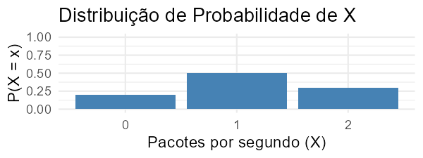

**Figura:** esta distribuição de probabilidade discreta representa a variável aleatória X, que assume os valores 0, 1 e 2 pacotes por segundo. A altura de cada barra indica a probabilidade P(X = x) de ocorrência de cada valor. Observa-se que o valor mais provável é X = 1 (50%), seguido de X = 2 (30%) e X = 0 (20%). Esse tipo de visualização ajuda a compreender a concentração de probabilidade e a assimetria de uma distribuição discreta.

```r
library(ggplot2)
library(base64enc)
library(IRdisplay)

# Criar dataframe
df <- data.frame(X = factor(c(0, 1, 2)), P = c(0.2, 0.5, 0.3))

# Caminho temporário
img_path <- tempfile(fileext = ".png")

# Criar gráfico
p <- ggplot(df, aes(x = X, y = P)) +
  geom_bar(stat = "identity", fill = "steelblue") +
  labs(title = "Distribuição de Probabilidade de X",
       x = "Pacotes por segundo (X)", y = "P(X = x)") +
  ylim(0, 1) +
  theme_minimal()

# Salvar com tamanho reduzido
ggsave(filename = img_path, plot = p, width = 4, height = 1.5, dpi = 150)


# Codificar como base64
img_b64 <- dataURI(file = img_path, mime = "image/png")

# Exibir no notebook (centralizado)
display_html(sprintf('
<div style="text-align:center; max-width: 100%%;">
  <img src="%s" style="max-width: 100%%; height: auto;">
  <div style="margin-top:8px; font-size:90%%; color:#555; text-align:justify;">
    <b>Figura:</b> esta distribuição de probabilidade discreta representa a variável aleatória X,
    que assume os valores 0, 1 e 2 pacotes por segundo.
    A altura de cada barra indica a probabilidade P(X = x) de ocorrência de cada valor.
    Observa-se que o valor mais provável é X = 1 (50%%), seguido de X = 2 (30%%) e X = 0 (20%%).
    Esse tipo de visualização ajuda a compreender a concentração de probabilidade e a assimetria de uma distribuição discreta.
  </div>
</div>
', img_b64))
```

### Exercício 62

Para a variável aleatória do exercício anterior, calcule $P(X \leq 1)$ e $P(X > 0)$.

### Exercício 63

Verifique se as probabilidades fornecidas no exercício 61 constituem uma distribuição de probabilidade válida.

R – Sim, $\displaystyle \sum P(X = x) = 1$

### Exercícios 64–65

Um servidor monitora o número de tentativas de acesso por segundo.  
A variável $Y$ pode assumir os valores de $0$ a $4$, com probabilidades proporcionais a esses valores.

**64.** Determine a função de probabilidade de $Y$.

Como as probabilidades são proporcionais aos valores de $Y$, temos:  
$P(Y = y) = \dfrac{y}{\sum_{k=0}^{4} k} = \dfrac{y}{10}$, para $y = 0, 1, 2, 3, 4$  
Logo, $P(Y = 0) = 0$, $P(Y = 1) = 0.1$, $P(Y = 2) = 0.2$, $P(Y = 3) = 0.3$, $P(Y = 4) = 0.4$

**65.** Crie um gráfico de barras com os valores de $Y$ e suas respectivas probabilidades.

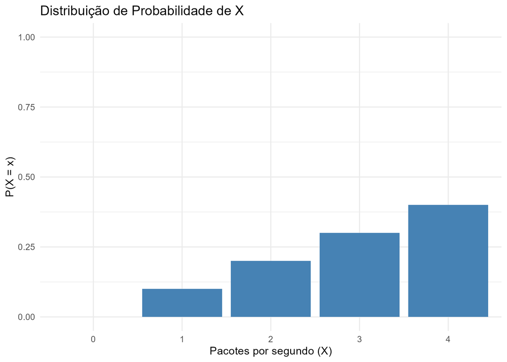

**Figura:** a distribuição apresentada mostra a probabilidade de X assumir valores entre 0 e 4 pacotes por segundo. Nota-se que a probabilidade cresce de forma contínua até atingir seu valor máximo em X = 4 (40%), indicando que valores maiores de X são mais prováveis nesta configuração. A visualização permite comparar rapidamente a frequência relativa de cada valor possível.

```r
library(ggplot2)
library(IRdisplay)

# Criar dataframe
df <- data.frame(X = factor(c(0, 1, 2, 3, 4)), P = c(0.0, 0.1, 0.2, 0.3, 0.4))

# img_path para salvar o gráfico
img_path <- "D:/g_drive/docencia/uff/disciplinas/posgrad/vis_rep_data/jupiter/figs/probabilidade_X.png"

# Criar o gráfico
p <- ggplot(df, aes(x = X, y = P)) +
  geom_bar(stat = "identity", fill = "steelblue") +
  labs(title = "Distribuição de Probabilidade de X",
       x = "Pacotes por segundo (X)", y = "P(X = x)") +
  ylim(0, 1) +
  theme_minimal()
# Salvar no diretório
ggsave(filename = img_path, plot = p, width = 7, height = 5, dpi = 300)

# Converter para base64
img_b64 <- dataURI(file = img_path, mime = "image/png")

# Exibir centralizado no notebook
display_html(sprintf('
<div style="text-align:center; max-width: 100%%;">
  <img src="%s" style="max-width: 100%%; height: auto;">
  <div style="margin-top:8px; font-size:90%%; color:#555; text-align:justify;">
    <b>Figura:</b> a distribuição apresentada mostra a probabilidade de X assumir valores entre 0 e 4 pacotes por segundo.
    Nota-se que a probabilidade cresce de forma contínua até atingir seu valor máximo em X = 4 (40%%),
    indicando que valores maiores de X são mais prováveis nesta configuração.
    A visualização permite comparar rapidamente a frequência relativa de cada valor possível.
  </div>
</div>
', img_b64))
```

### Exercício 66/67

Um pacote pode ser aceito ($1$) ou descartado ($0$).  
Defina a variável aleatória $Z$ associada a esse experimento e descreva sua distribuição de probabilidade.

A variável aleatória $Z$ assume valores em $\{0,1\}$.  
Essa é uma distribuição de Bernoulli, utilizada para modelar experimentos com dois resultados possíveis.

$\text{Distribuição de Bernoulli: } Z \in \{0,1\}$ $$ P(Z = z) = \begin{cases} p & \text{se } z = 1 \\\\ 1 - p & \text{se } z = 0 \\\\ 0 & \text{caso contrário} \end{cases} $$

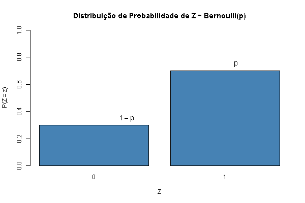

**Figura:** representação gráfica da distribuição de Bernoulli para a variável Z, onde $P(Z=1) = p$ e $P(Z=0) = 1 - p$. Essa forma de visualização é útil para compreender a natureza dicotômica do experimento, no qual o pacote pode ser aceito ou descartado.

```r
library(IRdisplay)
library(base64enc)

# Caminho temporário
img_path <- tempfile(fileext = ".png")

# Valores possíveis da variável Z
z <- c(0, 1)

# Probabilidades genéricas (valores arbitrários apenas para o desenho)
p_val <- 0.7
probs <- c(1 - p_val, p_val)

# Abrir dispositivo gráfico
png(filename = img_path, width = 600, height = 400)

# Criar gráfico de barras
barplot(probs, names.arg = z, col = "steelblue",
        main = "Distribuição de Probabilidade de Z ~ Bernoulli(p)",
        xlab = "Z", ylab = "P(Z = z)",
        ylim = c(0, 1))

# Adicionar rótulos simbólicos
text(x = 1, y = probs[1] + 0.05, labels = expression(1 - p), cex = 1.2)
text(x = 2, y = probs[2] + 0.05, labels = expression(p), cex = 1.2)

dev.off()

# Converter para base64
img_b64 <- dataURI(file = img_path, mime = "image/png")

# Exibir centralizado com descrição
display_html(sprintf('
<div style="text-align:center; max-width: 100%%;">
  <img src="%s" style="max-width: 100%%; height: auto;">
  <div style="margin-top:8px; font-size:90%%; color:#555; text-align:justify;">
    <b>Figura:</b> representação gráfica da distribuição de Bernoulli para a variável Z,
    onde $P(Z=1) = p$ e $P(Z=0) = 1 - p$. Essa forma de visualização é útil para compreender
    a natureza dicotômica do experimento, no qual o pacote pode ser aceito ou descartado.
  </div>
</div>
', img_b64))
```

### Exercício 68

Suponha uma variável $W$ que representa o número de links ativos entre 3 disponíveis. Liste o espaço amostral e associe os valores da variável.

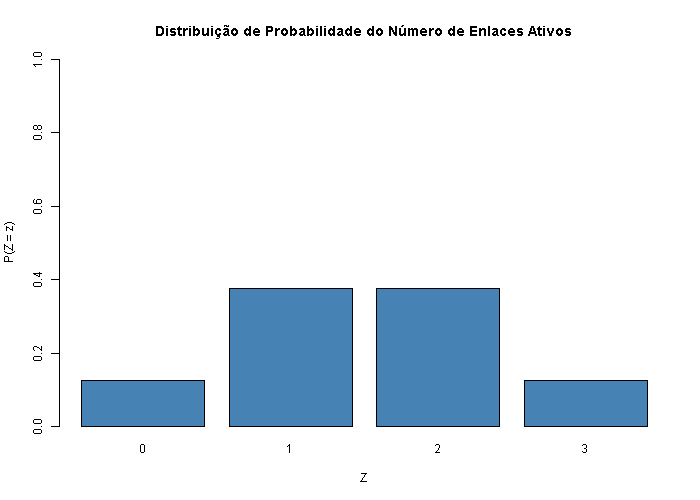

```r
# Pacotes necessários
library(IRdisplay)

# Criar diretório, se necessário
dir.create("D:/g_drive/docencia/uff/disciplinas/posgrad/vis_rep_data/jupiter/figs/", recursive = TRUE, showWarnings = FALSE)

# img_path do arquivo
img_path <- "D:/g_drive/docencia/uff/disciplinas/posgrad/vis_rep_data/jupiter/figs/enlaces_ativos.png"

# Abrir dispositivo gráfico para salvar
png(filename = img_path, width = 700, height = 500)

# Valores possíveis da variável Z
z <- c(0, 1, 2, 3)

# Probabilidades associadas
p <- c(1/8, 3/8, 3/8, 1/8)

# Gráfico de barras
barplot(p, names.arg = z, col = "steelblue",
        main = "Distribuição de Probabilidade do Número de Enlaces Ativos",
        xlab = "Z", ylab = "P(Z = z)",
        ylim = c(0, 1))

# Fechar dispositivo gráfico
invisible(dev.off())

# Converter para base64
img_b64 <- dataURI(file = img_path, mime = "image/png")

# Exibir centralizado no notebook
display_html(sprintf('
<div style="text-align:center; max-width: 100%%;">
  <img src="%s" style="max-width: 100%%; height: auto;">
  <div style="margin-top:8px; font-size:90%%; color:#555; text-align:justify;">
    <b>Figura:</b> distribuição de probabilidade do número de enlaces ativos,
    onde a variável aleatória $Z$ representa a contagem de enlaces simultaneamente em operação.
    A simetria na distribuição indica que configurações com dois enlaces ativos e
    configurações com apenas um ou três enlaces ativos possuem probabilidades iguais (3/8),
    enquanto os extremos (nenhum ou todos ativos) têm menor probabilidade (1/8).

  </div>
</div>
', img_b64))
```

### Exercícios 69/70

Defina a variável aleatória que representa o número de sucessos em 4 transmissões independentes, cada uma com probabilidade $0.8$ de sucesso.  
Usando R, gere o gráfico da distribuição de probabilidade da variável definida no exercício.

Para a solução deste exercício, primeiro temos que definir alguns termos:

- $n = 4$ como número de tentativas
- $\Omega = \{0,1,2,3,4\}$ como o possível número de sucessos
- $p = 0.8$ como a probabilidade de sucesso
- $1 - p = 0.2$ como a probabilidade de falha
- $k$ representa o número de sucessos

Podemos então modelar isso como uma função binomial de ensaios de Bernoulli, ou seja, 4 tentativas com resultados discretos (0 ou 1), onde 0 é falha e 1 é sucesso. A função de probabilidade associada é: $$ X \sim \text{Bin}(n, p) $$ Nota: dizemos que ${X∼Bin(n,p) = Bin(4,0.8)}$. A variável $ X$ segue uma distribuiçao binomial.

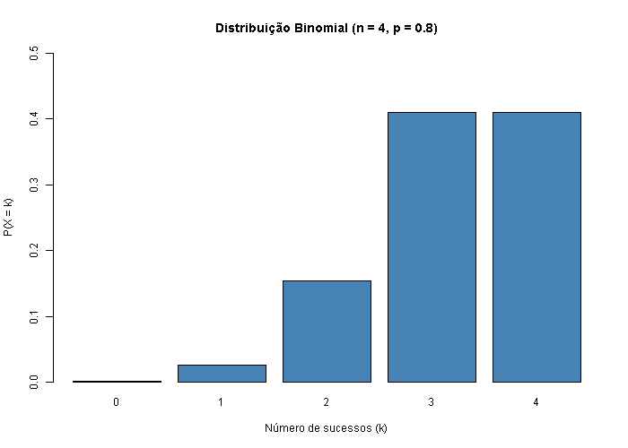

```r
# Pacotes
library(IRdisplay)

# Criar diretório, se necessário
dir.create("D:/g_drive/docencia/uff/disciplinas/posgrad/vis_rep_data/jupiter/figs", recursive = TRUE, showWarnings = FALSE)

# img_path do arquivo
img_path <- "D:/g_drive/docencia/uff/disciplinas/posgrad/vis_rep_data/jupiter/figs/binomial_n4_p08.png"

# Valores de k e parâmetros da binomial
k <- 0:4
n <- 4
p <- 0.8
y <- dbinom(k, size = n, prob = p)

# Salvar gráfico
png(filename = img_path, width = 700, height = 500)
barplot(y, names.arg = k, col = "steelblue",
        main = "Distribuição Binomial (n = 4, p = 0.8)",
        xlab = "Número de sucessos (k)", ylab = "P(X = k)",
        ylim = c(0, 0.5))
invisible(dev.off())

# Converter para base64
img_b64 <- dataURI(file = img_path, mime = "image/png")

# Exibir centralizado no notebook
display_html(sprintf('
<div style="text-align:center; max-width: 100%%;">
  <img src="%s" style="max-width: 100%%; height: auto;">
  <div style="margin-top:8px; font-size:90%%; color:#555; text-align:justify;">
    <b>Figura:</b> distribuição binomial com parâmetros $n = 4$ e $p = 0.8$.
    A variável aleatória $X$ representa o número de sucessos em quatro tentativas independentes,
    cada uma com probabilidade $p$ de sucesso.
    A maior probabilidade ocorre em $k = 4$ sucessos e a menor em $k = 0$,
    o que indica predominância de resultados com alto número de sucessos.
  </div>
</div>
', img_b64))
```

### Exercícios 71/72

Um IDS (sistema de detecção de intrusos) detecta entre 0 e 3 tentativas maliciosas por hora.  
As probabilidades são:

- $P(0) = 0.1$
- $P(1) = 0.3$
- $P(2) = 0.4$
- $P(3) = 0.2$

**71.** Modele graficamente.

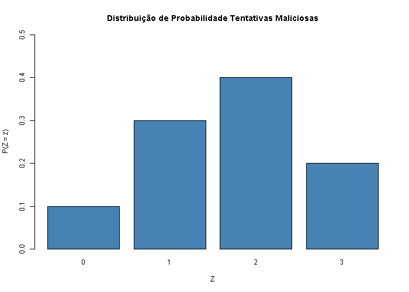

**Figura:** distribuição de probabilidade da variável $Z$, que representa o número de tentativas maliciosas observadas em um intervalo. A maior probabilidade ocorre em $Z = 2$, seguida de $Z = 1$ e $Z = 3$. O menor valor é observado em $Z = 0$, indicando que o cenário mais comum envolve múltiplas tentativas maliciosas.

```r
# Pacotes
library(IRdisplay)

# Criar diretório, se necessário
dir.create("D:/g_drive/docencia/uff/disciplinas/posgrad/vis_rep_data/jupiter/figs", recursive = TRUE, showWarnings = FALSE)

# img_path do arquivo
img_path <- "D:/g_drive/docencia/uff/disciplinas/posgrad/vis_rep_data/jupiter/figs/tentativas_maliciosas.png"

# Valores da variável Z e probabilidades
z <- c(0, 1, 2, 3)
p <- c(0.1, 0.3, 0.4, 0.2)

# Salvar gráfico
png(filename = img_path, width = 700, height = 500)
barplot(p, names.arg = z, col = "steelblue",
        main = "Distribuição de Probabilidade Tentativas Maliciosas",
        xlab = "Z", ylab = "P(Z = z)",
        ylim = c(0, 0.5))
invisible(dev.off())

# Converter para base64
img_b64 <- dataURI(file = img_path, mime = "image/png")

# Exibir centralizado no notebook
display_html(sprintf('
<div style="text-align:center; max-width: 100%%;">
  <img src="%s" style="max-width: 100%%; height: auto;">
  <div style="margin-top:8px; font-size:90%%; color:#555; text-align:justify;">
    <b>Figura:</b> distribuição de probabilidade da variável $Z$, que representa o número de tentativas maliciosas observadas em um intervalo.
    A maior probabilidade ocorre em $Z = 2$, seguida de $Z = 1$ e $Z = 3$.
    O menor valor é observado em $Z = 0$, indicando que o cenário mais comum envolve múltiplas tentativas maliciosas.
  </div>
</div>
', img_b64))
```

### Exercício 73

Uma variável aleatória $X$ tem distribuição dada por $P(X = k) = \dfrac{1}{n}$ para $k = 1, \dots, n$.  
Que nome se dá a essa distribuição?

Essa é a **distribuição uniforme discreta**, na qual todos os valores de $k$ têm a **mesma probabilidade**: $P(X = k) = \dfrac{1}{n}$, $k \in \{1, 2, \dots, n\}$.

### Exercícios 74/75

Um roteador recebe até 5 pacotes por segundo. A variável $X$ conta quantos pacotes chegam.  
Dê um exemplo de função de probabilidade que modele esse caso com **viés para números baixos** de pacotes por segundo.

Uma função de probabilidade com viés para valores baixos pode ser: $$ P(X = k) = \begin{cases} 0.30 & \text{se } k = 0 \\\\ 0.25 & \text{se } k = 1 \\\\ 0.20 & \text{se } k = 2 \\\\ 0.15 & \text{se } k = 3 \\\\ 0.06 & \text{se } k = 4 \\\\ 0.04 & \text{se } k = 5 \\\\ 0 & \text{caso contrário} \end{cases} $$

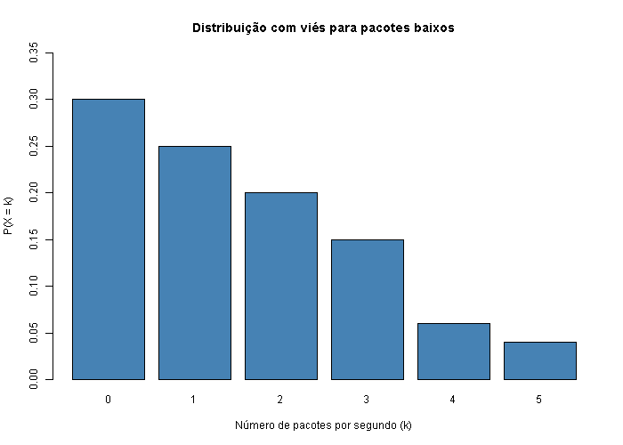

**Figura:** distribuição de probabilidade da variável $X$, que representa o número de pacotes por segundo. As maiores probabilidades estão associadas aos menores valores de $k$, com destaque para $k = 0$, indicando um viés na ocorrência de pacotes baixos.

```r
# Pacotes
library(IRdisplay)

# Criar diretório, se necessário
dir.create("D:/g_drive/docencia/uff/disciplinas/posgrad/vis_rep_data/jupiter/figs", recursive = TRUE, showWarnings = FALSE)

# img_path do arquivo
img_path <- "D:/g_drive/docencia/uff/disciplinas/posgrad/vis_rep_data/jupiter/figs/vies_pacotes_baixos.png"

# Valores e probabilidades
k <- 0:5
p <- c(0.30, 0.25, 0.20, 0.15, 0.06, 0.04)

# Salvar imagem
png(filename = img_path, width = 700, height = 500)
barplot(p, names.arg = k, col = "steelblue",
        main = "Distribuição com viés para pacotes baixos",
        xlab = "Número de pacotes por segundo (k)",
        ylab = "P(X = k)",
        ylim = c(0, 0.35))
invisible(dev.off())

# Exibir centralizado no notebook
# Converter para base64
img_b64 <- dataURI(file = img_path, mime = "image/png")

# Exibir centralizado no notebook
display_html(sprintf('
<div style="text-align:center; max-width: 100%%;">
  <img src="%s" style="max-width: 100%%; height: auto;">
  <div style="margin-top:8px; font-size:90%%; color:#555; text-align:justify;">
    <b>Figura:</b> distribuição de probabilidade da variável $X$, que representa o número de pacotes por segundo.
    As maiores probabilidades estão associadas aos menores valores de $k$, com destaque para $k = 0$,
    indicando um viés na ocorrência de pacotes baixos.
  </div>
</div>
', img_b64))
```

### Exercício 76/77

Uma variável $X$ representa o número de falhas em 4 enlaces.  
Cada enlace pode falhar com probabilidade $0.2$.  
Defina a distribuição e justifique. $k = 0,1,2,3$

Para a solução deste exercício, primeiro temos que definir alguns termos:

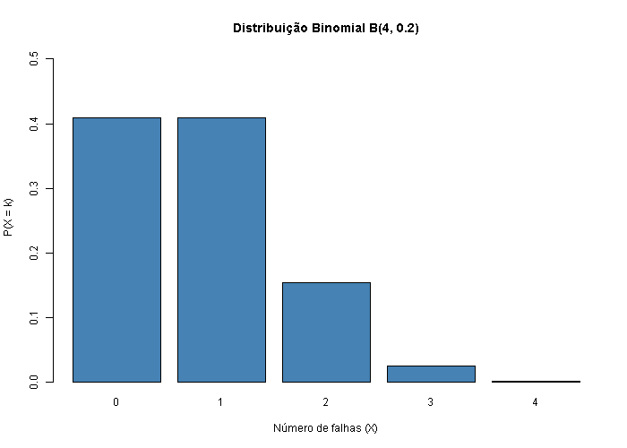

```r
# Pacotes
library(IRdisplay)

# Criar diretório se necessário
dir.create("D:/g_drive/docencia/uff/disciplinas/posgrad/vis_rep_data/jupiter/figs", recursive = TRUE, showWarnings = FALSE)

# img_path do arquivo
img_path <- "D:/g_drive/docencia/uff/disciplinas/posgrad/vis_rep_data/jupiter/figs/binomial_falhas_enlaces.png"

# Parâmetros da binomial
n <- 4
p <- 0.2
k <- 0:n
prob <- dbinom(k, size = n, prob = p)

# Salvar gráfico
png(filename = img_path, width = 700, height = 500)
barplot(prob,
        names.arg = k,
        col = "steelblue",
        main = "Distribuição Binomial B(4, 0.2)",
        xlab = "Número de falhas (X)",
        ylab = "P(X = k)",
        ylim = c(0, max(prob) + 0.1))
invisible(dev.off())

# Converter para base64
img_b64 <- dataURI(file = img_path, mime = "image/png")

# Exibir centralizado no notebook
display_html(sprintf('
<div style="text-align:center; max-width: 100%%;">
  <img src="%s" style="max-width: 100%%; height: auto;">
  <div style="margin-top:8px; font-size:90%%; color:#555; text-align:justify;">
    <b>Figura:</b> distribuição binomial $B(4, 0.2)$ da variável aleatória $X$, que representa o número de falhas em quatro enlaces.
    A maior probabilidade ocorre em $k = 1$, seguida de $k = 0$ e $k = 2$, mostrando que eventos com poucas falhas são mais prováveis.
  </div>
</div>
', img_b64))
```

**Exercício 78 – Distribuição Binomial: Limites de $p$**

**Quando $p \rightarrow 0$:**

- A distribuição se concentra em $X = 0$
- A maioria das amostras terá zero sucessos
- O gráfico exibe um pico acentuado em $X = 0$

**Quando $p \rightarrow 1$:**

- A distribuição se concentra em $X = n$
- Quase todas as amostras terão sucesso
- O gráfico mostra um pico acentuado em $X = n$

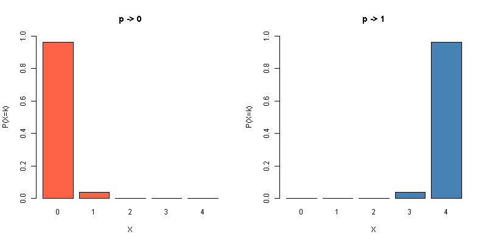

**Figura:** distribuições binomiais $B(4, p)$ para dois casos extremos: $p \to 0$ e $p \to 1$. No primeiro caso, a probabilidade concentra-se em $k = 0$, enquanto no segundo caso a concentração está em $k = 4$. Esses cenários mostram como valores extremos de $p$ resultam em distribuições altamente concentradas em um único valor de $k$.

```r
# Criar e salvar os dois gráficos lado a lado no diretório atual (para exibição no notebook)
png("binomial_p0_p1.png", width = 800, height = 400)
par(mfrow = c(1, 2))

# Valores
k <- 0:4
n <- 4

p1 <- dbinom(k, size = n, prob = 0.01)
p2 <- dbinom(k, size = n, prob = 0.99)

barplot(p1, names.arg = k, col = "tomato",
        main = "p -> 0", xlab = "X", ylab = "P(X=k)", ylim = c(0,1))

barplot(p2, names.arg = k, col = "steelblue",
        main = "p -> 1", xlab = "X", ylab = "P(X=k)", ylim = c(0,1))
invisible(dev.off())

# Copiar a figura para o diretório externo
invisible(file.copy("binomial_p0_p1.png",
          to = "D:/g_drive/docencia/uff/disciplinas/posgrad/vis_rep_data/jupiter/figs/binomial_p0_p1.png",
          overwrite = TRUE))

# Ajustar o caminho para a imagem gerada
img_path <- "D:/g_drive/docencia/uff/disciplinas/posgrad/vis_rep_data/jupiter/figs/binomial_p0_p1.png"

# Converter para base64
img_b64 <- dataURI(file = img_path, mime = "image/png")

# Exibir centralizado no notebook com legenda
display_html(sprintf('
<div style="text-align:center; max-width: 100%%;">
  <img src="%s" style="max-width: 100%%; height: auto;">
  <div style="margin-top:8px; font-size:90%%; color:#555; text-align:justify;">
    <b>Figura:</b> distribuições binomiais $B(4, p)$ para dois casos extremos: $p \\to 0$ e $p \\to 1$.
    No primeiro caso, a probabilidade concentra-se em $k = 0$, enquanto no segundo caso a concentração está em $k = 4$.
    Esses cenários mostram como valores extremos de $p$ resultam em distribuições altamente concentradas em um único valor de $k$.
  </div>
</div>
', img_b64))
```

**Exercício 79 – Modelagem com Binomial e Animação**

Em um sistema de autenticação, a variável aleatória ( X ) representa o número de logins bem-sucedidos em 3 tentativas.

Modelamos com:

$ X \sim \text{Bin}(3, p), \qquad P(X = k) = \binom{3}{k}p^k (1-p)^{3-k}, \quad k = 0,1,2,3$$ Abaixo, uma animação com a variação de $ p \in \{0.1, 0.2, ..., 1.0\} $.

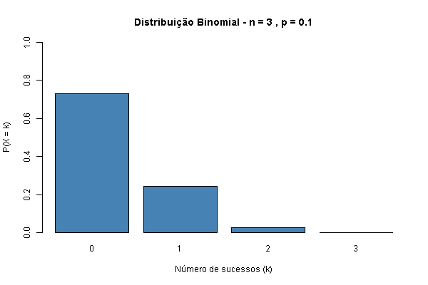

**Figura:** animação da distribuição binomial $B(3, p)$ variando o valor de $p$ de 0,1 até 1,0. A probabilidade concentra-se nos valores de $k$ mais próximos de $np$, mostrando como o formato da distribuição se desloca e se modifica conforme $p$ aumenta.

```r
# Instale os pacotes se necessário
# install.packages("animation")
# install.packages("base64enc")
# install.packages("IRdisplay")

library(animation)
library(base64enc)
library(IRdisplay)

# Número de tentativas
n <- 3
k <- 0:n

# Função para plotar a distribuição binomial
binom_plot <- function(p) {
  y <- dbinom(k, size = n, prob = p)
  barplot(y,
          names.arg = k,
          col = "steelblue",
          ylim = c(0, 1),
          main = paste("Distribuição Binomial - n =", n, ", p =", round(p, 1)),
          xlab = "Número de sucessos (k)",
          ylab = "P(X = k)")
}

# img_path do arquivo GIF
gif_path <- "D:/g_drive/docencia/uff/disciplinas/posgrad/vis_rep_data/jupiter/figs/binomial_animation.gif"

# Suprimir todas as saídas do saveGIF
invisible({
  sink(tempfile())  # Redireciona saída padrão
  try(
    suppressMessages(suppressWarnings(
      saveGIF({
        for (p in seq(0.1, 1, by = 0.1)) {
          binom_plot(p)
        }
      }, movie.name = gif_path,
         interval = 0.8, ani.width = 600, ani.height = 400)
    )),
    silent = TRUE
  )
  sink()  # Restaura a saída padrão
})

# Codificar o GIF como base64 (silencioso)
invisible(gif_b64 <- dataURI(file = gif_path, mime = "image/gif"))

display_html(sprintf('
<div style="text-align:center; max-width: 100%%;">
  <img src="%s" style="max-width: 100%%; height: auto;">
  <div style="margin-top:8px; font-size:90%%; color:#555; text-align:justify;">
    <b>Figura:</b> animação da distribuição binomial $B(3, p)$ variando o valor de $p$ de 0,1 até 1,0.
    A probabilidade concentra-se nos valores de $k$ mais próximos de $np$,
    mostrando como o formato da distribuição se desloca e se modifica conforme $p$ aumenta.
  </div>
</div>
', gif_b64))
```

### Exercício 81

Qual a variância da variável definida no exercício 80?

### Exercícios 82/83/84

Se uma variável $X$ assume os valores $1$, $2$, $3$ com probabilidades $0.2$, $0.5$, $0.3$, calcule o valor esperado $E[X]$ e $\mathrm{Var}(X)$.

O valor esperado $E[X]$ de uma variável aleatória discreta é calculado como uma média ponderada dos seus possíveis valores.  
A fórmula é:

$$E[X] = \sum_k k \cdot P(X = k)$$

Ou seja, cada valor $k$ que a variável pode assumir é ponderado pela sua probabilidade $P(X = k)$, e todos esses produtos são somados.  
Essa definição é válida para qualquer variável aleatória discreta.

Por exemplo, se $X$ assume os valores $1$, $2$ e $3$ com probabilidades $0.2$, $0.5$ e $0.3$, então:

$$E[X] = 1 \cdot 0.2 + 2 \cdot 0.5 + 3 \cdot 0.3 = 2.1$$

O valor esperado representa, nesse caso, o “centro de massa” da distribuição. Ver gráfico ao lado

Para a variância, usamos a fórmula:
$$\mathrm{Var}(X) = \sum_k \left(k - \mu \right)^2 \cdot P(X = k)$$

Com $\mu = E[X] = 2.1$, temos:
$$\mathrm{Var}(X) = (1 - 2.1)^2 \cdot 0.2 + (2 - 2.1)^2 \cdot 0.5 + (3 - 2.1)^2 \cdot 0.3 = 0.49$$

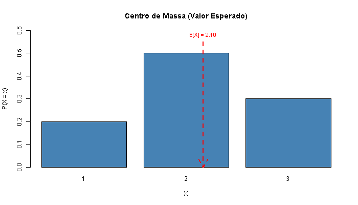

**Figura:** distribuição de probabilidade da variável $X$ com valores $1$, $2$ e $3$. A linha tracejada em vermelho indica o valor esperado $E[X] = 2.10$, representando o centro de massa da distribuição.

```r
library(base64enc)
library(IRdisplay)

# Dados da população
x <- 1:3
p <- c(0.2, 0.5, 0.3)

# Valor esperado (centro de massa)
E_X <- sum(x * p)

# Variância populacional (com divisor n)
var_pop <- sum((x - E_X)^2 * p)
#invisible(cat(sprintf("Var(X) = %.4f\n", var_pop)))  # Esperado: 0.49

# img_paths de salvamento
local_path <- "valor_esperado_pop.png"
img_path <- "D:/g_drive/docencia/uff/disciplinas/posgrad/vis_rep_data/jupiter/figs/valor_esperado_pop.png"

# Salvar figura
png(local_path, width = 700, height = 400)

# Gráfico de barras
barplot(p, names.arg = x, col = "steelblue",
        main = "Centro de Massa (Valor Esperado)",
        xlab = "X", ylab = "P(X = x)", ylim = c(0, max(p) + 0.1))

# Adicionar linha e texto do valor esperado
arrows(x0 = E_X, y0 = max(p) + 0.05,
       x1 = E_X, y1 = 0, col = "red", lwd = 2, lty = 2)
text(E_X, max(p) + 0.08, labels = sprintf("E[X] = %.2f", E_X),
     col = "red", cex = 0.9)

invisible(dev.off())  # Fecha o dispositivo gráfico

# Copiar imagem para pasta final
invisible(file.copy(local_path, img_path, overwrite = TRUE))

# Converter para base64
img_b64 <- dataURI(file = img_path, mime = "image/png")

# Exibir centralizado no notebook
display_html(sprintf('
<div style="text-align:center; max-width: 100%%;">
  <img src="%s" style="max-width: 100%%; height: auto;">
  <div style="margin-top:8px; font-size:90%%; color:#555; text-align:justify;">
    <b>Figura:</b> distribuição de probabilidade da variável $X$ com valores $1$, $2$ e $3$.
    A linha tracejada em vermelho indica o valor esperado $E[X] = %.2f$,
    representando o centro de massa da distribuição.
  </div>
</div>
', img_b64, E_X))
```

### Exercício 85

Uma variável aleatória $X$ representa o número de retransmissões em uma transmissão com no máximo 2 tentativas.  
Liste os valores possíveis e proponha uma função de probabilidade.

$X \sim \text{Bin}(2,\ p)$  
$P(X = k) = \binom{2}{k} \cdot p^k \cdot (1 - p)^{2 - k}, \quad k = 0,1,2$

### Exercício 86

Modele graficamente a distribuição do exercício 85 para diferentes taxas de sucesso.  
Variações em $p$ afetam a forma da distribuição binomial: valores mais altos de $p$ deslocam a massa para $k = 2$, enquanto valores baixos concentram em $k = 0$.

### Exercício 87/88

Um analisador de pacotes classifica conexões como normal ($0$) ou anômala ($1$) com probabilidade $0.95$ e $0.05$ respectivamente.  
Represente essa variável e sua distribuição.  
Mostre como o gráfico da distribuição de $X$ se altera se a taxa de anomalias aumentar para $0.20$.

Há múltiplos cenários possíveis de modelagem:

- 1. Se detectar anomalia for considerado sucesso: $X \sim \text{Bern}(0.05)$
- 2. Se detectar conexão normal for sucesso: $X \sim \text{Bern}(0.95)$
- 3. Se cada tentativa visa detectar anomalia entre $n$ conexões: $X \sim \text{Bin}(n, 0.05)$
- 4. Se normal for o evento de interesse em $n$ conexões: $X \sim \text{Bin}(n, 0.95)$

Com o aumento da taxa de anomalias para $0.20$, o valor de $p$ muda nos modelos 1 e 3, o que desloca a massa da distribuição para valores maiores de $X$.

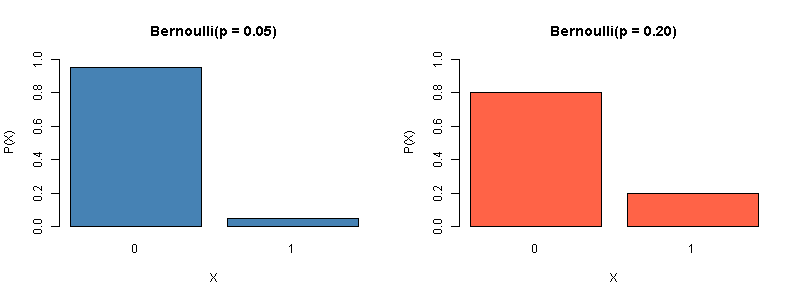

**Figura:** comparação de distribuições de Bernoulli para $p = 0.05$ e $p = 0.20$. À medida que $p$ aumenta, a probabilidade associada a $X = 1$ cresce e a de $X = 0$ diminui, modificando a concentração da distribuição.

```r
# Criar e salvar os dois gráficos lado a lado no diretório atual
png("bernoulli_comparativo.png", width = 800, height = 300)
par(mfrow = c(1, 2))

# Valores possíveis de X
x <- c(0, 1)

# Probabilidades para p = 0.05
p1 <- c(0.95, 0.05)

# Probabilidades para p = 0.20
p2 <- c(0.80, 0.20)

# Primeiro gráfico
barplot(p1, names.arg = x, col = "steelblue",
        main = "Bernoulli(p = 0.05)", xlab = "X", ylab = "P(X)",
        ylim = c(0, 1))

# Segundo gráfico
barplot(p2, names.arg = x, col = "tomato",
        main = "Bernoulli(p = 0.20)", xlab = "X", ylab = "P(X)",
        ylim = c(0, 1))
invisible(dev.off())

# Copiar para diretório externo
invisible(file.copy("bernoulli_comparativo.png",
          to = "D:/g_drive/docencia/uff/disciplinas/posgrad/vis_rep_data/jupiter/figs/bernoulli_comparativo.png",
          overwrite = TRUE))
img_path = "D:/g_drive/docencia/uff/disciplinas/posgrad/vis_rep_data/jupiter/figs/bernoulli_comparativo.png"

# Converter para base64
img_b64 <- dataURI(file = img_path, mime = "image/png")

# Exibir centralizado no notebook
display_html(sprintf('
<div style="text-align:center; max-width: 100%%;">
  <img src="%s" style="max-width: 100%%; height: auto;">
  <div style="margin-top:8px; font-size:90%%; color:#555; text-align:justify;">
    <b>Figura:</b> comparação de distribuições de Bernoulli para $p = 0.05$ e $p = 0.20$.
    À medida que $p$ aumenta, a probabilidade associada a $X = 1$ cresce e a de $X = 0$ diminui,
    modificando a concentração da distribuição.
  </div>
</div>
', img_b64))
```

### Exercício 89

Um sistema de backup realiza entre $0$ e $3$ tentativas por hora. Calcule a esperança e compare graficamente duas distribuições discretas com mesma média mas variâncias diferentes  
Suponha que:

- $P(0) = 0.5$
- $P(1) = 0.3$
- $P(2) = 0.15$
- $P(3) = 0.05$

Para calcular o valor esperado $E[X]$, usamos a fórmula: $$ E[X] = \sum_{k=0}^{3} k \cdot P(X = k) $$ Substituindo os valores: $$ E[X] = 0 \cdot 0.5 + 1 \cdot 0.3 + 2 \cdot 0.15 + 3 \cdot 0.05 = 0 + 0.3 + 0.3 + 0.15 = 0.75 $$ Logo, $E[X] = 0.75$

TRUE

[figure not shown]

```r
# Carregar biblioteca
library(IRdisplay)

# Intervalo para X
k_full <- 0:50
k_a <- 0:20

# Distribuições com mesma média, mas variâncias diferentes
p_A <- dbinom(k_a, size = 20, prob = 0.5)       # Menor variância
p_B <- dbinom(k_full, size = 200, prob = 0.05)  # Maior variância

# Salvar figura como PNG
png("comparacao_dispersao.png", width = 900, height = 400)
par(mfrow = c(1, 2))

barplot(p_A, names.arg = k_a, col = "steelblue",
        main = "Bin(20, 0.5) - Menor dispersão",
        ylab = "P(X = k)", xlab = "k", ylim = c(0, max(p_A, p_B)))

barplot(p_B, names.arg = k_full, col = "tomato",
        main = "Bin(200, 0.05) - Maior dispersão",
        ylab = "P(X = k)", xlab = "k", ylim = c(0, max(p_A, p_B)))



# Gerar e salvar a figura original
png("comparacao_dispersao.png", width = 800, height = 400)
plot(1:10, 1:10, main = "Exemplo Comparação Dispersão")
dev.off()  # fecha o dispositivo e grava o arquivo

# Copiar imagem para pasta de destino
file.copy("comparacao_dispersao.png",
          to = "D:/g_drive/docencia/uff/disciplinas/posgrad/vis_rep_data/jupiter/figs/comparacao_dispersao.png",
          overwrite = TRUE)

# Definir caminho final
img_path <- "D:/g_drive/docencia/uff/disciplinas/posgrad/vis_rep_data/jupiter/figs/comparacao_dispersao.png"

# Converter para base64
library(base64enc)
library(IRdisplay)
img_b64 <- dataURI(file = img_path, mime = "image/png")

# Exibir centralizado no notebook
display_html(sprintf('
<div style="text-align:center; max-width: 100%%;">
  <img src="%s" style="max-width: 100%%; height: auto;">
  <div style="margin-top:8px; font-size:90%%; color:#555; text-align:justify;">
    <b>Figura:</b> comparação de duas distribuições binomiais com a mesma média e variâncias diferentes.
    A primeira, $B(20, 0.5)$, apresenta menor dispersão em torno da média, enquanto a segunda, $B(200, 0.05)$, apresenta maior dispersão.
    A diferença na largura das distribuições ilustra o efeito da variância sobre a concentração das probabilidades.
  </div>
</div>
', img_b64))
```

### Exercício 91

Um sistema realiza 4 testes com probabilidade $0.9$ de sucesso em cada.  
Defina a variável número de falhas e modele sua distribuição.

$X \sim \text{Bin}(4,\ 0.1)$ $P(X = k) = \binom{4}{k} \cdot 0.1^k \cdot (0.9)^{4 - k}, \quad k = 0,1,2,3,4$

### Exercício 92

Qual a esperança e variância da variável do exercício 91?

$X_A \sim \text{Bin}(4,\ 0.1)$ com variância populacional: $\mathrm{Var}(X_A) = n \cdot p \cdot (1 - p) = 4 \cdot 0.1 \cdot (1 - 0.1) = 0.36$

### Exercício 93

Um sistema tolera no máximo 1 falha entre 3 enlaces. Modele a distribuição do número de falhas e desenhe seu gráfico.  
Vamos reescrever este problema.  
Um dado sistema $S$ continua funcionando se ocorrerem 0 ou 1 falha, então estamos interessados em estimar a probabilidade dos casos:

$P(X \leq 1) = P(X = 0) + P(X = 1)$

Mais ainda, na distribuição binomial

$|\Omega| = n+1 \Rightarrow \Omega =\{\emptyset, L_1, L_2, L_3\} \Rightarrow n = 3$

Então a distribuição pode ser representada por $X_A \sim \text{Bin}(3, p)$, assim: $P(X = k) = \binom{3}{k} \cdot p^k \cdot (1 - p)^{3 - k}, \quad k = 0,1,2,3$

### Exercício 94

Um firewall bloqueia pacotes com probabilidade $0.1$. Para 5 pacotes, modele a variável que conta quantos são bloqueados.

Neste caso, $\Omega = \{0,1,2,3,4,5\} \Rightarrow |\Omega| = n+1 = 6 \Rightarrow n = 5$. Assim: $P(X = k) = \binom{5}{k} \cdot 0.1^k \cdot (0.9)^{5 - k}, \quad k = 0,1,2,3,4,5$

### Exercício 95

Gere a função de probabilidade do exercício 94 no R e interprete.

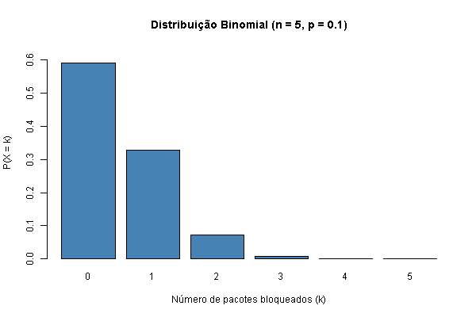

```r
library(base64enc)
library(IRdisplay)

# Parâmetros
n <- 5
p <- 0.1
k <- 0:n

# Probabilidades da distribuição binomial
y <- dbinom(k, size = n, prob = p)

# Salvar figura como PNG
png("binomial_pacotes_bloqueados.png", width = 600, height = 400)

# Gráfico
barplot(y, names.arg = k, col = "steelblue",
        main = "Distribuição Binomial (n = 5, p = 0.1)",
        xlab = "Número de pacotes bloqueados (k)",
        ylab = "P(X = k)",
        ylim = c(0, max(y) + 0.05))

invisible(dev.off())

# Copiar para diretório externo, se necessário
invisible(file.copy("binomial_pacotes_bloqueados.png",
          to = "D:/g_drive/docencia/uff/disciplinas/posgrad/vis_rep_data/jupiter/figs/binomial_pacotes_bloqueados.png",
          overwrite = TRUE))

# Converter para base64 para funcionar no nbviewer
img_b64 <- dataURI(file = "binomial_pacotes_bloqueados.png", mime = "image/png")

# Exibir centralizado no notebook
display_html(sprintf('
<div style="display: flex; flex-direction: column; justify-content: center; align-items: center; height: 100vh;">
  <div style="text-align:center">
    <img src="%s" width="600">
    <div style="margin-top:8px; font-size:90%%; color:#555; text-align:justify;">
      Figura 1: a maior barra está em $k=0$, indicando que o evento mais provável é nenhum pacote ser bloqueado,
      com probabilidade próxima a 60%%. Isso se deve à baixa probabilidade de bloqueio ($p=0.1$).
      A cauda longa e a assimetria à esquerda são características de distribuições binomiais com probabilidades próximas de zero.
    </div>
  </div>
</div>
', img_b64))
```

### Exercício 96.

Como o gráfico do exercício 94 muda se a taxa de bloqueio for $0,5$?

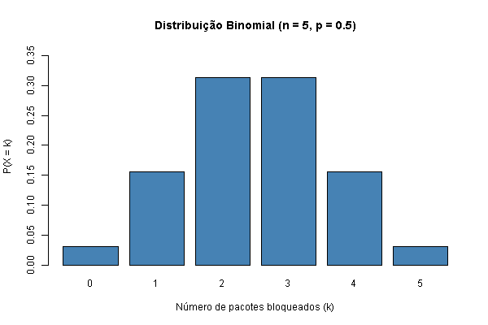

**Figura:** distribuição binomial $B(5, 0.5)$ da variável $X$, que representa o número de pacotes bloqueados em cinco tentativas independentes. A simetria em torno de $k = 2$ e $k = 3$ resulta do fato de $p = 0.5$, que torna sucessos e falhas igualmente prováveis, concentrando a maior parte da probabilidade nos valores próximos à média $np = 2.5$.

```r
# Parâmetros
n <- 5
p <- 0.5
k <- 0:n

# Probabilidades da distribuição binomial
y <- dbinom(k, size = n, prob = p)

# Salvar figura como PNG
png("binomial_pacotes_bloqueados_p05.png", width = 600, height = 400)

# Gráfico
barplot(y, names.arg = k, col = "steelblue",
        main = "Distribuição Binomial (n = 5, p = 0.5)",
        xlab = "Número de pacotes bloqueados (k)",
        ylab = "P(X = k)",
        ylim = c(0, max(y) + 0.05))

invisible(dev.off())

# Copiar para diretório externo, se necessário
invisible(file.copy("binomial_pacotes_bloqueados_p05.png",
          to = "D:/g_drive/docencia/uff/disciplinas/posgrad/vis_rep_data/jupiter/figs/binomial_pacotes_bloqueados_p05.png",
          overwrite = TRUE))

# Exibir centralizado no notebook
library(IRdisplay)

display_html(sprintf('
<div style="text-align:center; max-width: 100%%;">
  <img src="%s" style="max-width: 100%%; height: auto;">
  <div style="margin-top:8px; font-size:90%%; color:#555; text-align:justify;">
    <b>Figura:</b> distribuição binomial $B(5, 0.5)$ da variável $X$, que representa o número de pacotes bloqueados em cinco tentativas independentes.
    A simetria em torno de $k = 2$ e $k = 3$ resulta do fato de $p = 0.5$, que torna sucessos e falhas igualmente prováveis,
    concentrando a maior parte da probabilidade nos valores próximos à média $np = 2.5$.
  </div>
</div>
', dataURI(file = "D:/g_drive/docencia/uff/disciplinas/posgrad/vis_rep_data/jupiter/figs/binomial_pacotes_bloqueados_p05.png", mime = "image/png")))
```

### Exercício 97/98

Podemos escrever a distribuição de Poisson como: $$ P(X = k) = \frac{e^{-np} \cdot (np)^k}{k!} $$ A distribuição de Poisson é ideal para modelar **eventos raros**, ou seja, eventos com baixa probabilidade de ocorrência individual em pequenos intervalos de tempo ou espaço. Esse comportamento emerge da aproximação de Poisson para a binomial quando $p \to 0$ e $n \to \infty$, com $np = \lambda$ constante. Assim, a fórmula geral da distribuição de Poisson com parâmetro $\lambda$ é: $$ P(X = k) = \frac{\lambda^k \cdot e^{-\lambda}}{k!} $$ Para $\lambda = 1$, basta substituir na fórmula e calcular para $k = 0, 1, 2, 3$.

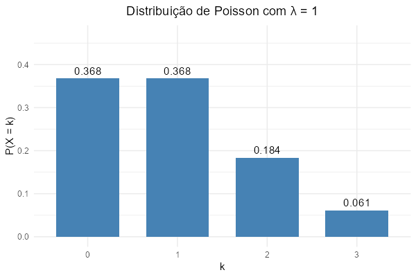

```r
library(ggplot2)
library(base64enc)
library(IRdisplay)

# --- Parâmetros da distribuição ---
k <- 0:3
lambda <- 1
prob <- dpois(k, lambda)

# --- Criar dataframe para ggplot ---
df <- data.frame(k = factor(k), prob = prob)

# --- Criar gráfico com ggplot2 ---
p <- ggplot(df, aes(x = k, y = prob)) +
  geom_bar(stat = "identity", fill = "steelblue", width = 0.7) +
  geom_text(aes(label = round(prob, 3)), vjust = -0.5, size = 4) +
  labs(title = expression(paste("Distribuição de Poisson com ", lambda, " = 1")),
       x = "k",
       y = "P(X = k)") +
  ylim(0, max(prob) + 0.1) +
  theme_minimal() +
  theme(plot.title = element_text(hjust = 0.5))

# --- Salvar como PNG e converter para base64 ---
img_path <- tempfile(fileext = ".png")
ggsave(img_path, p, width = 6, height = 4, dpi = 100)
img_b64 <- base64enc::dataURI(file = img_path, mime = "image/png")

# --- Exibir no Jupyter com legenda ---
display_html(sprintf('
<div style="text-align:center; margin:20px 0;">
  <img src="%s" style="max-width:100%%; height:auto;">
  <div style="margin-top:10px; font-size:0.9em; color:#555;">
    Figura: Distribuição de Poisson com $\\lambda = 1$. A maior probabilidade ocorre em $k = 1$.
  </div>
</div>', img_b64))
```

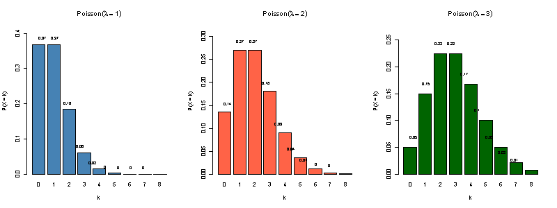

Figura: a visualização dos gráficos abaixo mostra que com o crescimento de lambda, a distribuição de Poisson tende a se comportar como a normal. Na realidade para valores próximos de $\lambda=30$ é comum essa análise. Para $\lambda=1$ a curva formada pelos histogramas da esquerda para a direita é claramente assimétrica, tendendo à simetrização com o aumento de $\lambda$.

```r
library(base64enc)
library(IRdisplay)

# --- Gerar e salvar a figura ---
png("poisson_lambdas.png", width = 800, height = 300)

# Suporte da variável
k <- 0:8

# Configurar layout: 1 linha, 3 colunas
par(mfrow = c(1, 3))

# Vetor de lambdas e cores
lambdas <- c(1, 2, 3)
cores <- c("steelblue", "tomato", "darkgreen")

# Loop para plotar os 3 gráficos
for (i in seq_along(lambdas)) {
  lambda <- lambdas[i]
  p <- dpois(k, lambda)
  barplot(p, names.arg = k, col = cores[i],
          main = bquote(Poisson(lambda == .(lambda))),
          xlab = "k", ylab = "P(X = k)", ylim = c(0, max(p) + 0.05))
  text(x = seq_along(k), y = p + 0.02, labels = round(p, 2), cex = 0.8)
}

invisible(dev.off())

# Copiar para diretório externo (opcional)
invisible(file.copy("poisson_lambdas.png",
                    to = "D:/g_drive/docencia/uff/disciplinas/posgrad/vis_rep_data/jupiter/figs/poisson_lambdas.png",
                    overwrite = TRUE))

# Converter para base64
img_b64 <- dataURI(file = "poisson_lambdas.png", mime = "image/png")

# Exibir figura centralizada no Jupyter
display_html(sprintf('
  <div style="display: flex; flex-direction: column; justify-content: center; align-items: center; height: 100vh;">
    div style="text-align:center; max-width: 100%%;">
      <img src="%s" width="700">
      <div style="margin-top:8px; font-size:90%%; color:#555;">
        Figura: a visualização dos gráficos abaixo mostra que com o crescimento de lambda,
        a distribuição de Poisson tende a se comportar como a normal.
        Na realidade para valores próximos de $\\lambda=30$ é comum essa análise.
        Para $\\lambda=1$ a curva formada pelos histogramas da esquerda para a direita é claramente assimétrica,
        tendendo à simetrização com o aumento de $\\lambda$.
      </div>
    </div>
  </div>
', img_b64))
```

### Exercício 99

Em redes congestionadas, o número de perdas por segundo pode seguir Poisson. Justifique essa escolha de modelo.

A distribuição de Poisson é adequada para modelar eventos discretos, raros e independentes, que ocorrem em um intervalo fixo de tempo ou espaço. Em redes congestionadas, mesmo que as perdas aumentem, o número de pacotes perdidos por segundo ainda é, em geral, muito menor que o número total de pacotes transmitidos, ou seja, $P \gg \lambda$, com $\lambda$ representando a taxa média de perdas. Quando temos:

- um número elevado de tentativas $n$
- cada tentativa com probabilidade de perda $p$ pequena
- e o produto $\lambda = n \cdot p$ constante

então o número de perdas por segundo tende a seguir uma Poisson com parâmetro $\lambda$. Isso decorre do **teorema do limite de Poisson**, que aproxima a binomial $B(n, p)$ por $Poisson(\lambda)$ quando $n \to \infty$ e $p \to 0$ com $np = \lambda$ constante.

### Exercício 100

Um sensor gera pacotes com taxa média de 2 por segundo. Modele o número de pacotes por segundo com uma distribuição adequada e represente graficamente.

Vamos aplicar a distribuição de Poisson, onde $k$ é o número de pacotes: $X \sim \text{Poisson}(\lambda = 2)$ A função de probabilidade é: $P(X = k) = \frac{\lambda^k e^{-\lambda}}{k!}$

$P(X = k) = \frac{2^k e^{-2}}{k!}, \quad k = 0, 1, 2, \dots$

### Exercício 101

Para a variável do exercício 100, qual a esperança e a variância?

A variável aleatória $X \sim \text{Poisson}(\lambda)$ possui função de massa de probabilidade dada por:

$P(X = k) = \frac{\lambda^k e^{-\lambda}}{k!}, \quad \text{para } k = 0, 1, 2, \dots$

O valor esperado é:

$E[X] = \sum_{k=0}^{\infty} k \cdot \frac{\lambda^k e^{-\lambda}}{k!}$

Com mudança de índice e manipulação algébrica, obtém-se: $E[X] = \lambda$

A variância é dada por: $\text{Var}(X) = E[X^2] - (E[X])^2$

Sabendo que: $E[X^2] = \lambda^2 + \lambda$

Logo: $$ \text{Var}(X) = \lambda $$

Demonstração: $E[X^2] = \sum_{k=0}^{\infty} k^2 \cdot \frac{\lambda^k e^{-\lambda}}{k!}$

Note que $k^2 = k(k-1) + k$. Assim: $E[X^2] = \sum_{k=0}^{\infty} [k(k-1) + k] \cdot \frac{\lambda^k e^{-\lambda}}{k!} = T_1 + T_2$

Onde:

- $T_1 = \sum_{k=0}^{\infty} k(k-1) \cdot \frac{\lambda^k e^{-\lambda}}{k!} = \lambda^2$
- $T_2 = \sum_{k=0}^{\infty} k \cdot \frac{\lambda^k e^{-\lambda}}{k!} = E[X] = \lambda$

Portanto: $$ E[X^2] = \lambda^2 + \lambda $$

E: $$ \text{Var}(X) = \lambda^2 + \lambda - \lambda^2 = \lambda $$

$$ \Rightarrow \text{Var}(X) = E[X] $$

### Exercício 102

Uma interface sem fio transmite pacotes com probabilidade de sucesso $p = 0.95$. Para $n = 10$ transmissões, modele a variável $X$ como o número de pacotes recebidos com sucesso.

Modelamos como:

$ X \sim \text{Bin}(10, 0.95), \qquad P(X = k) = \binom{10}{k}0.95^k (0.05)^{10-k}, \quad k = 0,1,2,3... 10$

---

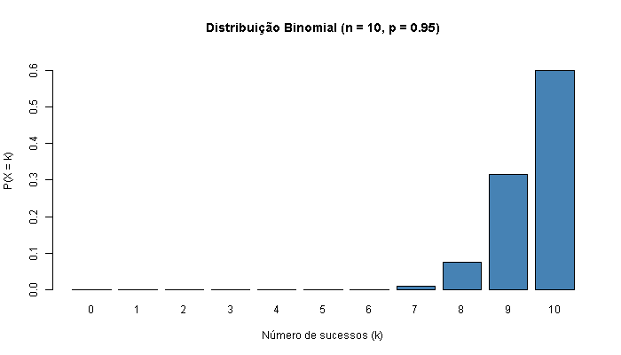

**Figura:** distribuição binomial $B(10, 0.95)$ da variável $X$, que representa o número de sucessos em dez tentativas independentes. A probabilidade concentra-se nos valores mais próximos de $k = 10$, refletindo a alta probabilidade de sucesso em cada tentativa. Isso resulta em uma distribuição assimétrica à esquerda, com baixa probabilidade para valores pequenos de $k$.

```r
# Instale os pacotes se necessário
# install.packages("base64enc")
# install.packages("IRdisplay")

library(base64enc)
library(IRdisplay)

# Parâmetros da binomial
n <- 10
p <- 0.95
k <- 0:n
y <- dbinom(k, size = n, prob = p)

# img_path do arquivo PNG
img_path <- "D:/g_drive/docencia/uff/disciplinas/posgrad/vis_rep_data/jupiter/figs/binomial_n10_p95.png"

# Gerar o gráfico e salvar (em silêncio)
invisible({
  png(img_path, width = 700, height = 400)
  barplot(y,
          names.arg = k,
          col = "steelblue",
          ylim = c(0, max(y) + 0.05),
          main = "Distribuição Binomial (n = 10, p = 0.95)",
          xlab = "Número de sucessos (k)",
          ylab = "P(X = k)")
  invisible(dev.off())
})

# Codificar imagem como base64
invisible(img_b64 <- dataURI(file = img_path, mime = "image/png"))

display_html(sprintf('
<div style="text-align:center; max-width: 100%%;">
  <img src="%s" style="max-width: 100%%; height: auto;">
  <div style="margin-top:8px; font-size:90%%; color:#555; text-align:justify;">
    <b>Figura:</b> distribuição binomial $B(10, 0.95)$ da variável $X$, que representa o número de sucessos em dez tentativas independentes.
    A probabilidade concentra-se nos valores mais próximos de $k = 10$, refletindo a alta probabilidade de sucesso em cada tentativa.
    Isso resulta em uma distribuição assimétrica à esquerda, com baixa probabilidade para valores pequenos de $k$.
  </div>
</div>
', img_b64))
```

### Exercício 103

Uma fila de espera em um roteador recebe em média $\lambda = 3$ requisições por segundo. Modele o número de chegadas por segundo  
$\quad$

- Se há $\lambda$, a distribuição é de Poisson: $X \sim \text{Pois}(\lambda)$
- Variável Aleatória $X$ representa o número de pacotes recebidos por segundo com taxa média $\lambda = 3$
- Distribuição discreta, com maior concentração de probabilidade em torno de $k = 3$

Modelamos como:

$X \sim \text{Pois}(3), \qquad P(X = k) = \frac{3^k e^{-3}}{k!}, \quad k = 0,1,2,\cdots, 10 $

### Exercício 104

Um firewall analisa $n = 20$ conexões. Cada conexão tem $p = 0.1$ de ser considerada maliciosa. Modele o número de conexões maliciosas:  
$\quad$

Modelamos como:

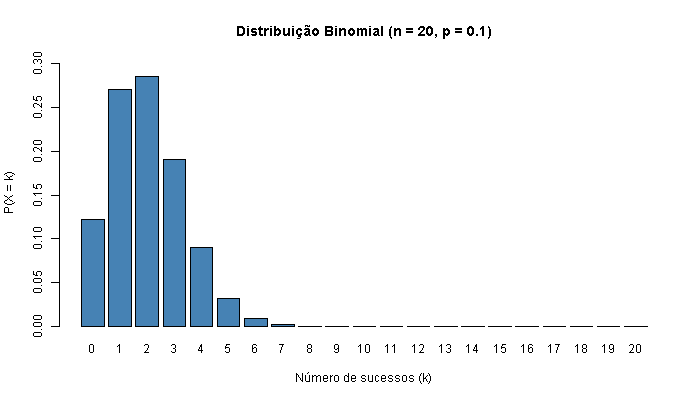

**Figura:** distribuição binomial $B(20, 0.1)$ da variável $X$, que representa o número de sucessos em vinte tentativas independentes. A probabilidade concentra-se nos valores próximos de $k = 2$, que corresponde à média $np = 2$. A baixa probabilidade de sucesso em cada tentativa gera uma distribuição assimétrica à direita, com cauda estendida para valores maiores de $k$.

```r
# Carregar bibliotecas necessárias
library(base64enc)
library(IRdisplay)

# Parâmetros da distribuição binomial
n <- 20
p <- 0.1
k <- 0:n
y <- dbinom(k, size = n, prob = p)

# img_path para salvar a figura
img_path <- "D:/g_drive/docencia/uff/disciplinas/posgrad/vis_rep_data/jupiter/figs/binomial_n20_p01.png"

# Gerar e salvar o gráfico (modo silencioso)
invisible({
  png(img_path, width = 700, height = 400)
  barplot(y,
          names.arg = k,
          col = "steelblue",
          ylim = c(0, max(y) + 0.02),
          main = "Distribuição Binomial (n = 20, p = 0.1)",
          xlab = "Número de sucessos (k)",
          ylab = "P(X = k)")
  invisible(dev.off())
})

# Codificar imagem como base64
invisible(img_b64 <- dataURI(file = img_path, mime = "image/png"))

display_html(sprintf('
<div style="text-align:center; max-width: 100%%;">
  <img src="%s" style="max-width: 100%%; height: auto;">
  <div style="margin-top:8px; font-size:90%%; color:#555; text-align:justify;">
    <b>Figura:</b> distribuição binomial $B(20, 0.1)$ da variável $X$, que representa o número de sucessos em vinte tentativas independentes.
    A probabilidade concentra-se nos valores próximos de $k = 2$, que corresponde à média $np = 2$.
    A baixa probabilidade de sucesso em cada tentativa gera uma distribuição assimétrica à direita, com cauda estendida para valores maiores de $k$.
  </div>
</div>
', img_b64))
```

### Exercício 105

Um sensor de presença envia em média 2 alertas por hora. Modele o número de alertas por hora:  
$\quad$ Se $\lambda$ é dado, muito provavelmente isto é uma distribuição de Poisson.

$X \sim \text{Pois}(\lambda)$  
$P(X = k) = \dfrac{2^k e^{-2}}{k!}$

### Exercício 106

Em um link óptico transmite-se $n = 30$ pacotes com taxa de erro de $p = 0.02$. Modele o número de pacotes com erro:  
$\quad$

- $X∼\text{Bin}(30,0.02), P(X=k)=\binom{30} {k}(0.02)^{k}(1-0.02)^{30-k}, k=0,1,2,…,30$

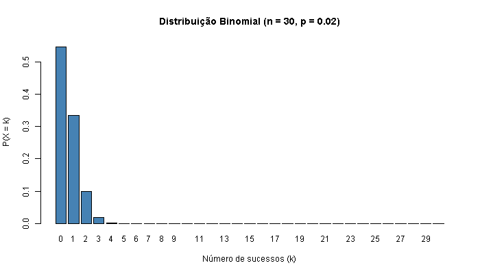

**Figura:** distribuição binomial $B(30, 0.02)$ da variável $X$, que representa o número de sucessos em trinta tentativas independentes. A probabilidade concentra-se fortemente em $k = 0$ e $k = 1$, refletindo a raridade do evento de sucesso. A baixa taxa de sucesso provoca uma distribuição altamente assimétrica à direita, com valores grandes de $k$ apresentando probabilidades próximas de zero.

```r
# Instale os pacotes se necessário
# install.packages("base64enc")
# install.packages("IRdisplay")

library(base64enc)
library(IRdisplay)

# Parâmetros da binomial
n <- 30
p <- 0.02
k <- 0:n
y <- dbinom(k, size = n, prob = p)

# img_path para salvar o gráfico
img_path <- "D:/g_drive/docencia/uff/disciplinas/posgrad/vis_rep_data/jupiter/figs/binomial_n30_p02.png"

# Gerar e salvar a figura (sem ruído)
invisible({
  png(img_path, width = 700, height = 400)
  barplot(y,
          names.arg = k,
          col = "steelblue",
          ylim = c(0, max(y) + 0.02),
          main = "Distribuição Binomial (n = 30, p = 0.02)",
          xlab = "Número de sucessos (k)",
          ylab = "P(X = k)")
  invisible(dev.off())
})

# Codificar em base64
invisible(img_b64 <- dataURI(file = img_path, mime = "image/png"))

# Exibir centralizado (vertical + horizontal)
display_html(sprintf('
<div style="text-align:center; max-width: 100%%;">
  <img src="%s" style="max-width: 100%%; height: auto;">
  <div style="margin-top:8px; font-size:90%%; color:#555; text-align:justify;">
    <b>Figura:</b> distribuição binomial $B(30, 0.02)$ da variável $X$, que representa o número de sucessos em trinta tentativas independentes.
    A probabilidade concentra-se fortemente em $k = 0$ e $k = 1$, refletindo a raridade do evento de sucesso.
    A baixa taxa de sucesso provoca uma distribuição altamente assimétrica à direita, com valores grandes de $k$ apresentando probabilidades próximas de zero.
  </div>
</div>
', img_b64))
```

### Exercício 107

Um sistema de autenticação registra, em média, $\lambda = 5$ falhas de login por minuto em horário de pico. Modele o número de falhas por minuto:  
$\quad$ $P(X=k)=\frac{5^{k}e^{-5}}{k!}$

### Exercício 108

Em uma transmissão de dados, $n = 15$ pacotes são enviados com probabilidade de sucesso $p = 0.9$. Modele o número de sucessos:  
$\quad$

$X \sim \text{Bin}(15,\ 0.9)$ $\displaystyle P(X = k) = \binom{15}{k} \cdot 0.9^k \cdot (1 - 0.9)^{15 - k}, \quad k = 0, 1, 2, \dots, 15$

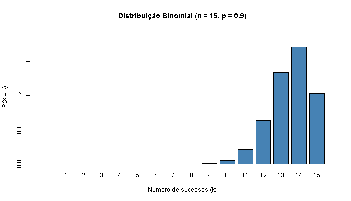

**Figura:** distribuição binomial $B(15, 0.9)$ da variável $X$, que representa o número de sucessos em quinze tentativas independentes. A probabilidade concentra-se em valores próximos de $k = 14$ e $k = 15$, refletindo a alta taxa de sucesso por tentativa. A distribuição apresenta assimetria à esquerda, com baixa probabilidade para valores pequenos de $k$.

```r
# Instale os pacotes se necessário
# install.packages("base64enc")
# install.packages("IRdisplay")

library(base64enc)
library(IRdisplay)

# Parâmetros
n <- 15
p <- 0.9
k <- 0:n
y <- dbinom(k, size = n, prob = p)

# img_path do arquivo
img_path <- "D:/g_drive/docencia/uff/disciplinas/posgrad/vis_rep_data/jupiter/figs/binomial_n15_p09.png"

# Gerar e salvar a figura (silenciosamente)
invisible({
  png(img_path, width = 700, height = 400)
  barplot(y,
          names.arg = k,
          col = "steelblue",
          ylim = c(0, max(y) + 0.05),
          main = "Distribuição Binomial (n = 15, p = 0.9)",
          xlab = "Número de sucessos (k)",
          ylab = "P(X = k)")
  invisible(dev.off())
})

# Codificar como base64
invisible(img_b64 <- dataURI(file = img_path, mime = "image/png"))

# Exibir centralizado vertical e horizontalmente
display_html(sprintf('
<div style="text-align:center; max-width: 100%%;">
  <img src="%s" style="max-width: 100%%; height: auto;">
  <div style="margin-top:8px; font-size:90%%; color:#555; text-align:justify;">
    <b>Figura:</b> distribuição binomial $B(15, 0.9)$ da variável $X$, que representa o número de sucessos em quinze tentativas independentes.
    A probabilidade concentra-se em valores próximos de $k = 14$ e $k = 15$, refletindo a alta taxa de sucesso por tentativa.
    A distribuição apresenta assimetria à esquerda, com baixa probabilidade para valores pequenos de $k$.
  </div>
</div>
', img_b64))
```

### Exercício 109

Um servidor Web recebe, em média, $\lambda = 10$ requisições por segundo. Modele a variável que conta o número de requisições por segundo:  
$\quad$

$\displaystyle P(X = k) = \frac{10^k \cdot e^{-10}}{k!}$

### Exercício 110

Um sistema de compressão falha em $p = 0.05$ dos casos. Para $n = 40$ compressões, modele o número de falhas:  
$\quad$

$X \sim \text{Bin}(40,\ 0.05)$ $\displaystyle P(X = k) = \binom{40}{k} \cdot 0.05^k \cdot (1 - 0.05)^{40 - k}, \quad k = 0, 1, 2, \dots, 40$

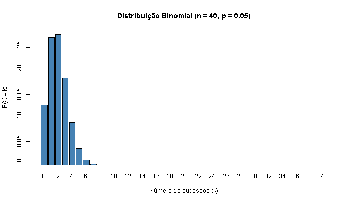

**Figura:** distribuição binomial $B(40, 0.05)$ da variável $X$, que representa o número de sucessos em quarenta tentativas independentes. A probabilidade concentra-se em valores próximos de $k = 2$, que corresponde à média $np = 2.0$. A baixa taxa de sucesso provoca uma distribuição assimétrica à direita, com valores maiores de $k$ apresentando probabilidades muito pequenas.

```r
# Instale os pacotes se necessário
# install.packages("base64enc")
# install.packages("IRdisplay")

library(base64enc)
library(IRdisplay)

# Parâmetros da binomial
n <- 40
p <- 0.05
k <- 0:n
y <- dbinom(k, size = n, prob = p)

# img_path da figura
img_path <- "D:/g_drive/docencia/uff/disciplinas/posgrad/vis_rep_data/jupiter/figs/binomial_n40_p05.png"

# Gerar e salvar figura silenciosamente
invisible({
  png(img_path, width = 700, height = 400)
  barplot(y,
          names.arg = k,
          col = "steelblue",
          ylim = c(0, max(y) + 0.01),
          main = "Distribuição Binomial (n = 40, p = 0.05)",
          xlab = "Número de sucessos (k)",
          ylab = "P(X = k)")
  invisible(dev.off())
})

# Codificar como base64
invisible(img_b64 <- dataURI(file = img_path, mime = "image/png"))

# Exibir centralizado no notebook (horizontal e vertical)
display_html(sprintf('
<div style="text-align:center; max-width: 100%%;">
  <img src="%s" style="max-width: 100%%; height: auto;">
  <div style="margin-top:8px; font-size:90%%; color:#555; text-align:justify;">
    <b>Figura:</b> distribuição binomial $B(40, 0.05)$ da variável $X$, que representa o número de sucessos em quarenta tentativas independentes.
    A probabilidade concentra-se em valores próximos de $k = 2$, que corresponde à média $np = 2.0$.
    A baixa taxa de sucesso provoca uma distribuição assimétrica à direita, com valores maiores de $k$ apresentando probabilidades muito pequenas.
  </div>
</div>
', img_b64))
```

### Exercício 111

O switch registra que 10% dos pacotes vêm da VLAN 10. Desses, 90% são legítimos. Nos demais, apenas 40% são legítimos.

✦ **Tarefa extra:** construa um diagrama (ex: árvore, gráfico de barras, ou Venn) que ajude a representar os eventos e probabilidades envolvidos.

**agg_record_2024102104:** 2

O switch registra que **10%** dos pacotes vêm da VLAN 10.  
Desses, **90%** são legítimos.  
Nos demais (**90%** dos pacotes), apenas **40%** são legítimos.

** Diagrama de Árvore Probabilística:**

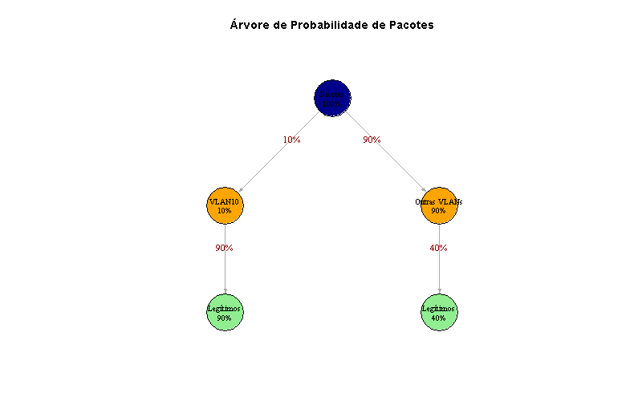

**Legenda:**

- **VLAN10 (10%):** 90% legítimos

- **Outras VLANs (90%):** 40% legítimos

- **Probabilidade total legítima:** (0.1 × 0.9) + (0.9 × 0.4) = **45%**

```r
# Carrega igraph silenciosamente e gerencia namespaces
suppressPackageStartupMessages({
  suppressWarnings(
    library(igraph, exclude = c("decompose", "spectrum", "union"))
  )
})  # Fechando ambos os parênteses que estavam abertos

# Dados da árvore de probabilidade
edges <- data.frame(
  from = c("Root", "Root", "VLAN10", "Outras"),
  to = c("VLAN10", "Outras", "Legítimo_VLAN10", "Legítimo_Outras"),
  label = c("10%", "90%", "90%", "40%")
)

# Rótulos dos nós
vertex_labels <- c(
  "Root" = "Pacotes\n100%",
  "VLAN10" = "VLAN10\n10%",
  "Outras" = "Outras VLANs\n90%",
  "Legítimo_VLAN10" = "Legítimos\n90%",
  "Legítimo_Outras" = "Legítimos\n40%"
)

# Cores dos nós
vertex_colors <- c(
  "Root" = "darkblue",
  "VLAN10" = "orange",
  "Outras" = "orange",
  "Legítimo_VLAN10" = "lightgreen",
  "Legítimo_Outras" = "lightgreen"
)

# Criar grafo
g <- graph_from_data_frame(edges)

# Caminho temporário da imagem
img_path <- tempfile(fileext = ".png")

# Salvar a árvore como PNG
png(img_path, width = 800, height = 500)
plot(
  g,
  layout = layout_as_tree(g, root = 1),
  vertex.size = 35,
  vertex.color = vertex_colors[names(V(g))],
  vertex.label = vertex_labels[names(V(g))],
  vertex.label.cex = 0.8,
  vertex.label.color = "black",
  edge.label = edges$label,
  edge.label.cex = 0.9,
  edge.label.color = "darkred",
  edge.arrow.size = 0.4,
  main = "Árvore de Probabilidade de Pacotes",
  margin = c(0,0,0.2,0)
)
dev.off()

# Converter para Base64 (usando a função correta)
library(base64enc)
img_b64 <- base64encode(img_path)

# Texto final com imagem embutida
texto_md <- sprintf('
O switch registra que **10%%** dos pacotes vêm da VLAN 10.
Desses, **90%%** são legítimos.
Nos demais (**90%%** dos pacotes), apenas **40%%** são legítimos.

** Diagrama de Árvore Probabilística:**

<img src="data:…" width="600">

**Legenda:**
<ul>
  <li><b>VLAN10 (10%%):</b> 90%% legítimos</li>
  <li><b>Outras VLANs (90%%):</b> 40%% legítimos</li>
  <li><b>Probabilidade total legítima:</b> (0.1 × 0.9) + (0.9 × 0.4) = <b>45%%</b></li>
</ul>
', img_b64)

# Exibir no notebook
library(IRdisplay)
display_markdown(texto_md)
```

**agg_record_647170950:** 2

O switch registra que **10%** dos pacotes vêm da VLAN 10.  
Desses, **90%** são legítimos.  
Nos demais (**90%** dos pacotes), apenas **40%** são legítimos.

**✦ Tarefa extra:** diagrama de árvore representando os eventos e probabilidades envolvidos.

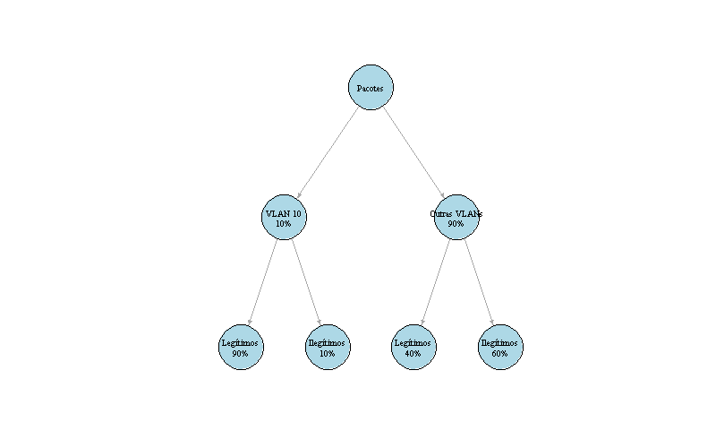

```r
library(igraph)
library(base64enc)
library(IRdisplay)

# Dados da árvore
edges <- data.frame(
  from = c("Pacotes", "Pacotes", "VLAN 10", "VLAN 10", "Outras VLANs", "Outras VLANs"),
  to   = c("VLAN 10", "Outras VLANs", "Legítimos VLAN 10", "Ilegítimos VLAN 10",
           "Legítimos outras VLANs", "Ilegítimos outras VLANs")
)

# Rótulos com probabilidades
labels <- c(
  "Pacotes",
  "VLAN 10\n10%",
  "Outras VLANs\n90%",
  "Legítimos\n90%",
  "Ilegítimos\n10%",
  "Legítimos\n40%",
  "Ilegítimos\n60%"
)

# Criar grafo
g <- graph_from_data_frame(edges)

# Caminho temporário da imagem
img_path <- tempfile(fileext = ".png")

# Salvar a árvore como PNG
png(img_path, width = 800, height = 500)
plot(
  g,
  layout = layout_as_tree(g, root = 1),
  vertex.size = 35,
  vertex.color = "lightblue",
  vertex.label = labels,
  vertex.label.cex = 0.8,
  vertex.label.color = "black",
  edge.arrow.size = 0.4
)
dev.off()

# Converter para Base64
img_b64 <- dataURI(file = img_path, mime = "image/png")

# Texto final com imagem embutida
texto_md <- sprintf('
O switch registra que **10%%** dos pacotes vêm da VLAN 10.
Desses, **90%%** são legítimos.
Nos demais (**90%%** dos pacotes), apenas **40%%** são legítimos.

**✦ Tarefa extra:** diagrama de árvore representando os eventos e probabilidades envolvidos.

<img src="%s" width="600">
', img_b64)

# Exibir no notebook
display_markdown(texto_md)
```

### Exercício 113

Uma rede possui dois enlaces redundantes: A e B. A entrega de pacotes depende de **pelo menos um deles estar operacional**. As estatísticas são:

- Enlace A falha com probabilidade $ P(F_A) = 0.02 $
- Enlace B falha com $ P(F_B) = 0.03 $
- As falhas são independentes

O SLA exige entrega **em 99% dos casos ou mais**.

✦ **Perguntas:**

1/2. Qual a **probabilidade de pelo menos um dos enlaces funcionar e a rede** cumpre o SLA** com essa configuração? Sim**?

Vamos primeiro montar o espaço amaostral para todos os casos Possiveis de A e B, on 0 e 1 são enlace em falha e em operação.

| A | B |
| --- | --- |
| 0 | 0 |
| 0 | 1 |
| 1 | 0 |
| 1 | 1 |

Então o caso em em que ambos falham é $ P(F_A)\cap P(F_A) = P(F_A)\cdot P(F_B) = 0.02 \cdot 0.03 = 0.0006$

De modo que todos os outros 3 casos estão contemplados em $1-P(F_A)\cap P(F_A) = 1-0.0006 = 99.94\%$. Então, sim a rede cumpre o SLA com este provisionamento.

### Exercício 114

Em uma rede 5G com agregação de portadoras, um usuário está conectado simultaneamente à **banda n78 (3,5 GHz)** e à **banda n258 (26 GHz)**. Cada uma pode, **independentemente**, sofrer queda de sessão com probabilidade de **5%**.

**Pergunta:**  
Qual a probabilidade de o usuário sofrer **interrupção total da sessão**, considerando que ela continua ativa se ao menos uma banda estiver funcional?

✦ **Tarefa extra:**

Construa um diagrama de **árvore de possibilidades**, gráfico de barras ou **diagrama de Venn** que represente:

- os **eventos de falha** em cada banda,
- a probabilidade de cada cenário possível

Vamos primeiro montar o espaço amaostral para todos os casos Possiveis de N78 e N258, on 0 e 1 são enlace em falha e em operação. Como N& e N2 são independentes P(n7) falhar é sempre 0.05 e P(n7) não falhar é sempre 0.95. Assim como P(n2) falhar é sempre 0.05 e P(n2) não falhar é sempre 0.95

| N7 | N2 | P |
| --- | --- | --- |
| 0 | 0 | $0.5 \cdot 0.5= 0.0025$ |
| 0 | 1 | $0.5 \cdot 0.95=0.0475$ |
| 1 | 0 | $0.95\cdot0.5=0.0475$ |
| 1 | 1 | $0.95\cdot0.95=0.9025$ |

De modo que todos os outros 3 casos estão contemplados em $1- P(F_{N7}\cap F_{N2}) = 1-0.0025= 99.75\%$.

### Exercício 115

Um sistema de firewall avançado aplica 3 regras em sequência. Cada regra bloqueia com 10%, 15% e 5%, independentemente.

**Tarefa extra:** construa um diagrama (ex: árvore, gráfico de barras, ou Venn) que ajude a representar os eventos e probabilidades envolvidos.

Vamos ao espaço amostral e probabilidades R1, R2 e R3 são as aplicações das regras, 000 não bloqueia e 111 bloqueia todas

| R1 | R2 | R3 | Probabilidade |
| --- | --- | --- | --- |
| 0 | 0 | 0 | 0,9 × 0,85 × 0,95 = 0,72675 |
| 0 | 0 | 1 | 0,9 × 0,85 × 0,05 = 0,03825 |
| 0 | 1 | 0 | 0,9 × 0,15 × 0,95 = 0,12825 |
| 0 | 1 | 1 | 0,9 × 0,15 × 0,05 = 0,00675 |
| 1 | 0 | 0 | 0,1 × 0,85 × 0,95 = 0,08075 |
| 1 | 0 | 1 | 0,1 × 0,85 × 0,05 = 0,00425 |
| 1 | 1 | 0 | 0,1 × 0,15 × 0,95 = 0,01425 |
| 1 | 1 | 1 | 0,1 × 0,15 × 0,05 = 0,00075 |

### Exercício 116

Em um sistema de comunicação, **1% dos pacotes são perdidos na transmissão inicial**. Quando isso ocorre, o sistema tenta uma **retransmissão imediata**, que tem **95% de chance de sucesso**.

**Pergunta:**  
Qual a probabilidade de um pacote precisar ser retransmitido **e ainda assim ser perdido**?

Considere um sistema em que pacotes podem ser perdidos na primeira transmissão e, se necessário, retransmitidos. As variáveis aleatórias $P$ (perda) e $R$ (retransmissão) indicam:

- $P = 1$: o pacote foi perdido na transmissão original
- $P = 0$: o pacote **não** foi perdido
- $R = 1$: o pacote foi retransmitido
- $R = 0$: o pacote **não** foi retransmitido

Sabemos que:

- $P(P = 1) = 0.01$ e $P(P = 0) = 0.99$
- $P(R = 1 \mid P = 0) = 0.05$
- $P(R = 1 \mid P = 1) = 0.95$

Vamos montar o espaço amostral e calcular as conjuntas usando:

- $P(0, 0) = P(P = 0) \cdot P(R = 0 \mid P = 0)$
- $P(0, 1) = P(P = 0) \cdot P(R = 1 \mid P = 0)$
- $P(1, 0) = P(P = 1) \cdot P(R = 0 \mid P = 1)$
- $P(1, 1) = P(P = 1) \cdot P(R = 1 \mid P = 1)$

| Perdidos | Retransmitidos | $P(\text{marg}) \cdot P(\text{cond})$ | $P(\text{total})$ |
| --- | --- | --- | --- |
| 0 | 0 | $0.99 \cdot 0.95$ | $0.9405$ |
| 0 | 1 | $0.99 \cdot 0.05$ | $0.0495$ |
| 1 | 0 | $0.01 \cdot 0.05$ | $0.0005$ |
| 1 | 1 | $0.01 \cdot 0.95$ | $0.0095$ |

A probabilidade de um pacote precisar ser retransmitido **e ainda assim ser perdido** é:

$$ P(P = 1 \cap R = 0) = \boxed{0.0005} $$

### Exercício 117

Um sistema de detecção de intrusão emite alerta com 98% de chance se há ataque, e 4% de falso positivo. A taxa de ataques reais é de 1%. Sabendo que o IDS emitiu um alerta, qual a probabilidade de realmente haver um ataque?

**Espaço amostral**

| Ataque (A) | Alerta (L) | Probabilidade Conjunta |
| --- | --- | --- |
| 0 | 0 | 0.99 × 0.96 = 0.9504 |
| 0 | 1 | 0.99 × 0.04 = 0.0396 |
| 1 | 0 | 0.01 × 0.02 = 0.0002 |
| 1 | 1 | 0.01 × 0.98 = 0.0098 |

**Cálculo:**

$ P(A\mid L) = \frac{P(A \cap L)}{P(L)} = \frac{0.01 \times 0.98}{0.0396 + 0.0098} \;=\; 0.1984 \;=\; \boxed{19.84\%} $

### Exercício 118

Dois sensores atuam **independentemente** na detecção de intrusos.

- O **Sensor A** acerta em 85% dos casos.
- O **Sensor B** acerta em 90% dos casos.

Considere que a presença de um intruso ocorre com **probabilidade 0.5**, e a ausência também com **0.5**.  
Cada sensor emite um alerta `1` (detecção) ou `0` (não detecção), e podem errar ou acertar independentemente.

**Pergunta:**  
Liste todos os pares possíveis de saída dos sensores na forma `(A, B) ∈ {0,1} × {0,1}`.

Vamos construir o espaço amostral, onde a coluna classe representa se há ou não intruso.

| Linha | Classe | A | B | P(Classe) | $P(\text{marg}) \cdot P(\text{cond})$ | P(Conjunta) |
| --- | --- | --- | --- | --- | --- | --- |
| 1 | 0 | 0 | 0 | 0.5 | 0.85 * 0.9 | 0.3825 |
| 2 | 0 | 0 | 1 | 0.5 | 0.85 * 0.1 | 0.0425 |
| 3 | 0 | 1 | 0 | 0.5 | 0.15 * 0.9 | 0.0675 |
| 4 | 0 | 1 | 1 | 0.5 | 0.15 * 0.1 | 0.0075 |
| 5 | 1 | 0 | 0 | 0.5 | 0.15 * 0.1 | 0.0075 |
| 6 | 1 | 0 | 1 | 0.5 | 0.15 * 0.9 | 0.0675 |
| 7 | 1 | 1 | 0 | 0.5 | 0.85 * 0.1 | 0.0425 |
| 8 | 1 | 1 | 1 | 0.5 | 0.85 * 0.9 | 0.3825 |

Sem saber a **classe real**, não conseguimos atribuir a **probabilidade correta de saída dos sensores**, pois a **acurácia depende da classe**.

A classe representa o **balanceamento do dataset**, ou seja, a proporção com que cada classe (por exemplo, "intruso" ou "sem intruso") aparece nos dados. Um dataset balanceado tem $ P(\text{Classe} = 0) = P(\text{Classe} = 1) = 0.5 $, por exemplo.

Para calcular a **probabilidade conjunta completa**, usamos:

$P(\text{Classe}, A, B) = P(\text{Classe}) \cdot P(A \mid \text{Classe}) \cdot P(B \mid \text{Classe})$

Portanto, **sem conhecer ( P(\text{Classe}) )**, não é possível calcular corretamente as **probabilidades conjuntas**, nem aplicar o **Teorema de Bayes** com rigor.

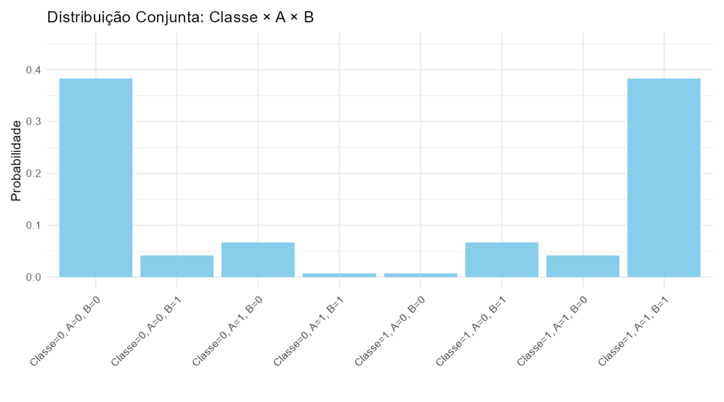

**Figura:** distribuição conjunta de (Classe, A, B). As probabilidades somam 1. A maior massa está nas combinações concordantes, (Classe=0, A=0, B=0) e (Classe=1, A=1, B=1), ambas com 0.3825. Combinações discordantes têm menor probabilidade, refletindo alinhamento entre Classe e saídas dos sensores A e B.

```r
# Pacotes
library(ggplot2)
library(base64enc)
library(IRdisplay)

# Dados
labels <- c(
  "Classe=0, A=0, B=0", "Classe=0, A=0, B=1", "Classe=0, A=1, B=0", "Classe=0, A=1, B=1",
  "Classe=1, A=0, B=0", "Classe=1, A=0, B=1", "Classe=1, A=1, B=0", "Classe=1, A=1, B=1"
)
probs <- c(0.3825, 0.0425, 0.0675, 0.0075, 0.0075, 0.0675, 0.0425, 0.3825)

df <- data.frame(Comb = factor(labels, levels = labels), Prob = probs)

# Gráfico (ggplot) — atribuir a 'p' para uso também no RGui
p <- ggplot(df, aes(x = Comb, y = Prob)) +
  geom_col(fill = "skyblue") +
  labs(title = "Distribuição Conjunta: Classe × A × B", x = NULL, y = "Probabilidade") +
  scale_y_continuous(limits = c(0, 0.45)) +
  coord_cartesian(clip = "off") +
  theme_minimal(base_size = 12) +
  theme(
    axis.text.x = element_text(angle = 45, hjust = 1),
    plot.margin = margin(10, 10, 30, 10)
  )

# Salvar e embutir em Base64 (para Jupyter)
img_path <- tempfile(fileext = ".png")
ggsave(filename = img_path, plot = p, width = 9, height = 5, dpi = 130)
img_b64 <- dataURI(file = img_path, mime = "image/png")

# Exibir com legenda justificada (Jupyter)
display_html(sprintf('
<div style="text-align:center; max-width:100%%;">
  <img src="%s" style="max-width:100%%; height:auto;">
  <div style="margin-top:12px; font-size:90%%; color:#555; text-align:justify; max-width:1000px; margin:0 auto;">
    <b>Figura:</b> distribuição conjunta de (Classe, A, B). As probabilidades somam 1.
    A maior massa está nas combinações concordantes, (Classe=0, A=0, B=0) e (Classe=1, A=1, B=1), ambas com 0.3825.
    Combinações discordantes têm menor probabilidade, refletindo alinhamento entre Classe e saídas dos sensores A e B.
  </div>
</div>
', img_b64))

# Observação: no RGui/RStudio, basta executar `print(p)` para visualizar o gráfico.
```

### Exercício 119 — Probabilidade de Disponibilidade em Redes Mesh

Em uma rede **mesh**, cada nó possui **90% de chance de estar disponível** em um dado instante.  
Considere dois nós distintos A e B , cujas **disponibilidades são independentes**.

**Pergunta:**  
Qual a probabilidade de os dois nós estarem disponíveis ao mesmo tempo?

Considere dois nós independentes. As variáveis aleatórias $A$ e $B$ representam a disponibilidade de cada nó:

- $A = 1$: nó A disponível
- $A = 0$: nó A indisponível
- $B = 1$: nó B disponível
- $B = 0$: nó B indisponível

Sabemos que $P(A = 0) = 0.10$ e $P(A = 1) = 0.90$, e o mesmo vale para $B$.  
Como os eventos são independentes, temos:

- $P(0, 0) = P(\bar{A}) \cdot P(\bar{B} \mid \bar{A})$
- $P(0, 1) = P(\bar{A}) \cdot P(B \mid \bar{A})$
- $P(1, 0) = P(A) \cdot P(\bar{B} \mid A)$
- $P(1, 1) = P(A) \cdot P(B \mid A)$

A tabela a seguir mostra os valores correspondentes:

| A_disp | B_disp | $P(\text{marg}) \cdot P(\text{cond})$ | $P(\text{conj.})$ |
| --- | --- | --- | --- |
| 0 | 0 | $P(\bar{A}) \cdot P(\bar{B} \mid \bar{A})$ | $0.01$ |
| 0 | 1 | $P(\bar{A}) \cdot P(B \mid \bar{A})$ | $0.09$ |
| 1 | 0 | $P(A) \cdot P(\bar{B} \mid A)$ | $0.09$ |
| 1 | 1 | $P(A) \cdot P(B \mid A)$ | $0.81$ |

A probabilidade de os dois nós **estarem simultaneamente disponíveis** é:

$$ P(A = 1 \cap B = 1) = \boxed{0.81} $$

### Exercício 120

Um sistema de replicação em nuvem envia cópias de cada pacote por **dois img_paths distintos e independentes**.  
A probabilidade de perda em **cada img_path** é de **1%**.  
Um pacote só é considerado perdido se **ambos os img_paths falharem simultaneamente**.

**✦ Tarefa extra:**  
Construa um diagrama (ex: **árvore de probabilidades**, **gráfico de barras** ou **diagrama de Venn**) que represente:

- Evento: "perda em um img_path"
- Evento: "recebimento em um img_path"
- Evento composto: "perda nos dois img_paths"

Vamos montar o espaço amostral e calcular as probabilidades conjuntas.  
Assuma:

- $P(\text{perda}) = 0.01$
- $P(\text{recebimento}) = 0.99$
- Eventos nos img_paths A e B são independentes.

Considere dois img_paths independentes. As variáveis aleatórias ( A ) e ( B ) indicam o **resultado da transmissão** em cada img_path:

- ( A = 0 ): perda no img_path A
- ( A = 1 ): recebimento no img_path A
- ( B = 0 ): perda no img_path B
- ( B = 1 ): recebimento no img_path B

A probabilidade de perda em um img_path é ( P(\bar{A}) = P(\bar{B}) = 0.01 ), e de recebimento é ( P(A) = P(B) = 0.99 ).  
Como os eventos são independentes, as probabilidades conjuntas podem ser calculadas como produto das marginais:

| A | B | $P(\text{marg}) \cdot P(\text{marg})$ | $P(\text{conj.})$ |
| --- | --- | --- | --- |
| 0 | 0 | $P(\bar{A}) \cdot P(\bar{B})$ | $0.0001$ |
| 0 | 1 | $P(\bar{A}) \cdot P(B)$ | $0.0099$ |
| 1 | 0 | $P(A) \cdot P(\bar{B})$ | $0.0099$ |
| 1 | 1 | $P(A) \cdot P(B)$ | $0.9801$ |

A perda total de um pacote ocorre apenas quando ambos os img_paths falham simultaneamente, isto é, ( A = 0 ) e ( B = 0 ). A probabilidade desse evento é:

$$ P(A = 0 \cap B = 0) = P(\bar{A} \cap \bar{B}) = \boxed{0.0001} $$

### Exercício 121

Uma conexão segura só é estabelecida se **três etapas criptográficas independentes** forem concluídas com sucesso.  
Cada etapa tem **probabilidade de sucesso igual a 0,99**.  
Falha em qualquer uma das etapas impede a conexão.

**✦ Tarefa extra:**  
Construa um diagrama (ex: **árvore de probabilidades**, **gráfico de barras** ou **diagrama de Venn**) que represente:

- Evento: "sucesso em uma etapa"
- Evento: "falha em uma etapa"
- Evento composto: "todas as etapas com sucesso" (conexão segura estabelecida)

Indique as probabilidades envolvidas e destaque a probabilidade total de sucesso da conexão.

probabilidade total de sucesso da conexão é 0.970299

### Exercício 122

O gráfico abaixo mostra a distribuição dos pacotes de rede por tipo de serviço.  
Os valores numéricos de cada barra estão indicados **explicitamente**.

**✦ Tarefas**

1. Quais são os eventos mutuamente exclusivos representados?
2. Qual é a probabilidade de um pacote não ser interativo?
3. Calcule a soma total das probabilidades. O que isso indica?
4. Podemos considerar essa distribuição como uma função de probabilidade discreta?
5. Supondo que maior proporção implique maior prioridade, qual serviço deve ser tratado com maior QoS (qualidade de serviço)?
6. Interprete o valor da barra menor em termos de comportamento da rede (ex: largura de banda, latência).

Respostas:

1. Interativo streaming e em lote
2. 55%
3. 1 - significa que todos os eventos estão representados, ou seja, representam completamente $\Omega$.
4. sim. são valores finitos e não contínuos
5. Interativo
6. Streaming, aceita alguma latencia

**agg_record_1766430715:** 2

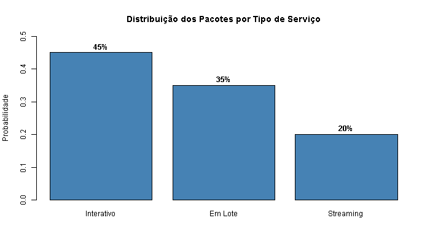

**Figura:** distribuição dos pacotes por tipo de serviço. O tipo interativo concentra 45% do total, seguido por processamento em lote com 35% e transmissão em streaming com 20%. Os valores indicam a proporção de cada categoria em relação ao total de pacotes.

```r
library(base64enc)
library(IRdisplay)

# Caminho temporário da imagem
img_path <- tempfile(fileext = ".png")

# Salvar o gráfico
png(img_path, width = 700, height = 400)
tipos <- c("Interativo" = 0.45,
           "Em Lote"    = 0.35,
           "Streaming"  = 0.20)

b <- barplot(tipos,
             col = "steelblue",
             main = "Distribuição dos Pacotes por Tipo de Serviço",
             ylab = "Probabilidade",
             ylim = c(0, 0.5))

# Adiciona os valores no topo das barras
text(x = b,
     y = tipos + 0.02,
     labels = paste0(round(tipos * 100), "%"),
     cex = 1,
     font = 2)
dev.off()

# Converter para base64
img_b64 <- dataURI(file = img_path, mime = "image/png")

# Exibir no notebook com legenda
display_html(sprintf('
<div style="text-align:center; max-width: 100%%;">
  <img src="%s" style="max-width: 100%%; height: auto;">
  <div style="margin-top:8px; font-size:90%%; color:#555; text-align:justify;">
    <b>Figura:</b> distribuição dos pacotes por tipo de serviço.
    O tipo interativo concentra 45%% do total, seguido por processamento em lote com 35%% e transmissão em streaming com 20%%.
    Os valores indicam a proporção de cada categoria em relação ao total de pacotes.
  </div>
</div>
', img_b64))
```

### Exercício 123 — Firewall e inferência bayesiana

Um firewall classifica pacotes de rede como **suspeitos** ou **não suspeitos**. Em uma amostra de tráfego inspecionado, observou-se a distribuição conjunta representado no gráfico:

- Calcule $P(\text{malicioso})$, $P(\text{suspeito})$
- Calcule $P(\text{malicioso} \mid \text{suspeito})$

Vamos montar o espaço amostral na Tabela 123 e calcular as conjuntas. 0 não malicioso/suspeito e 1 caso contrário:

| Suspeito | Malicioso | P(conj.) |
| --- | --- | --- |
| 0 | 0 | 0.784 |
| 0 | 1 | 0.016 |
| 1 | 0 | 0.080 |
| 1 | 1 | 0.120 |

Só havendo estados suspeito e malicioso, podemos escrever que os eventos Suspeitos = Suspeito que é malicioso + Suspeito que não é malicioso, daí empregando também a aditividade das probabilidades $P(A\cup B) = P(A) + P(B)$ temos que:

$$ S= (S\cap M) \cup (S \cap \bar{M}) \implies P(S)= P(S\cap M) \cup P(S \cap \bar{M}) $$

Da tabela 123, temos $P(S)= P(S\cap M) \cup P(S \cap \bar{M}) \implies P(S) = 0.12 + 0.080 \implies P(S)= 0.2$

**agg_record_190991923:** 2

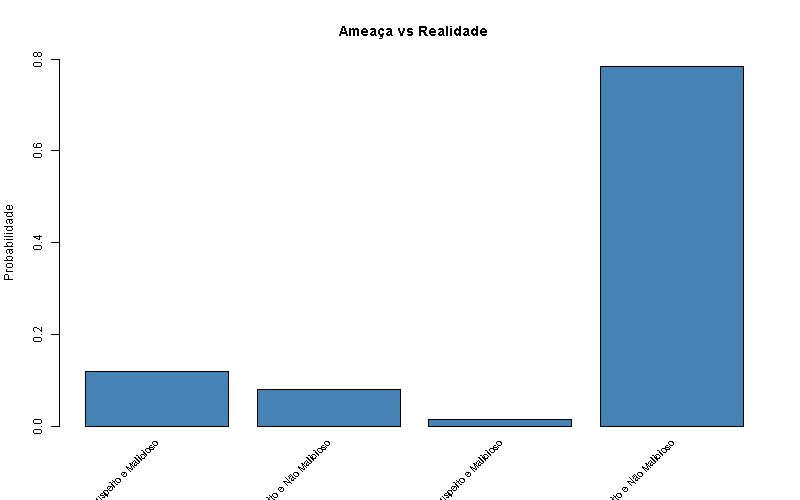

**Figura:** relação entre suspeita e ocorrência real de atividades maliciosas. A maior parte dos casos (78.4%) corresponde a eventos não suspeitos e não maliciosos. Casos suspeitos e maliciosos representam 12%, enquanto suspeitos e não maliciosos são 8%. Situações não suspeitas, mas maliciosas, somam 1.6%.

```r
library(base64enc)
library(IRdisplay)

# Caminho temporário para salvar a imagem
img_path <- tempfile(fileext = ".png")

# Salvar gráfico
png(img_path, width = 800, height = 500)
probs <- c(0.12, 0.08, 0.016, 0.784)
labels <- c("Suspeito e Malicioso", "Suspeito e Não Malicioso",
            "Não Suspeito e Malicioso", "Não Suspeito e Não Malicioso")

# Cria o barplot sem rótulos no eixo X
bp <- barplot(probs,
              names.arg = rep("", length(labels)),
              col = "steelblue",
              ylim = c(0, 0.8),
              main = "Ameaça vs Realidade",
              ylab = "Probabilidade")

# Adiciona os rótulos manualmente com rotação
text(x = bp,
     y = par("usr")[3] - 0.03,
     labels = labels,
     srt = 45,
     adj = 1,
     xpd = TRUE,
     cex = 0.8)
dev.off()

# Exibir embutido em base 64
img_b64 <- dataURI(file = img_path, mime = "image/png")

# Legenda no padrão
display_html(sprintf('
<div style="text-align:center; max-width: 100%%;">
  <img src="%s" style="max-width: 100%%; height: auto;">
  <div style="margin-top:8px; font-size:90%%; color:#555; text-align:justify;">
    <b>Figura:</b> relação entre suspeita e ocorrência real de atividades maliciosas.
    A maior parte dos casos (78.4%%) corresponde a eventos não suspeitos e não maliciosos.
    Casos suspeitos e maliciosos representam 12%%, enquanto suspeitos e não maliciosos são 8%%.
    Situações não suspeitas, mas maliciosas, somam 1.6%%.
  </div>
</div>
', img_b64))
```

### Exercício 124 — Atraso em rede LTE

Tarefas:

- Calcule $P(\text{atraso})$, $P(\text{urgente})$
- Calcule $P(\text{urgente} \mid \text{atraso})$

Vamos analisar a distribuição conjunta dos eventos **Urgente (U)** e **Atraso (A)**, conforme a Tabela 124:

| Urgente ($U$) | Atraso ($A$) | $P(U, A)$ |
| --- | --- | --- |
| 0 | 0 | 0.595 |
| 0 | 1 | 0.105 |
| 1 | 0 | 0.276 |
| 1 | 1 | 0.024 |

Utilizando a propriedade da aditividade para eventos disjuntos:

$$ P(A = 1) = P(A = 1 \cap U = 1) + P(A = 1 \cap U = 0) $$

Substituindo os valores da tabela:

$$ P(A = 1) = 0.024 + 0.105 = 0.129 $$

De forma análoga:

$$ P(U = 1) = 0.276 + 0.024 = 0.3 $$

Aplicando a definição de probabilidade condicional:

$$ P(U = 1 \mid A = 1) = \frac{P(U = 1 \cap A = 1)}{P(A = 1)} = \frac{0.024}{0.129} \approx 0.186 $$

**agg_record_499150344:** 2

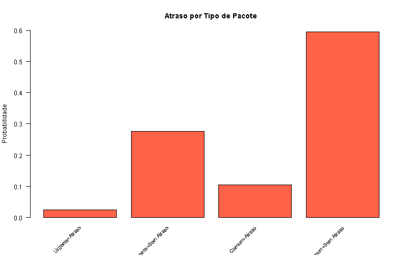

**Figura:** atraso por tipo de pacote. Pacotes urgentes com atraso representam 0.024 da probabilidade total, urgentes sem atraso 0.276, comuns com atraso 0.105 e comuns sem atraso 0.595. A distribuição evidencia que a maior parte dos pacotes é comum e sem atraso.

```r
library(base64enc)
library(IRdisplay)

# Caminho temporário da imagem
img_path <- tempfile(fileext = ".png")

# Salvar o gráfico
png(img_path, width = 800, height = 500)
probs <- c(0.30 * 0.08, 0.30 * 0.92, 0.70 * 0.15, 0.70 * 0.85)
labels <- c("Urgente+Atraso", "Urgente+Sem Atraso",
            "Comum+Atraso", "Comum+Sem Atraso")

# Cria o barplot
bp <- barplot(probs,
              names.arg = rep("", length(labels)),
              col = "tomato",
              las = 2,
              main = "Atraso por Tipo de Pacote",
              ylim = c(0, 0.6),
              ylab = "Probabilidade")

# Adiciona rótulos
text(x = bp,
     y = par("usr")[3] - 0.03,
     labels = labels,
     srt = 45,
     adj = 1,
     xpd = TRUE,
     cex = 0.8)
dev.off()

# Exibir embutido em Base64
img_b64 <- dataURI(file = img_path, mime = "image/png")

# Legenda no padrão
display_html(sprintf('
<div style="text-align:center; max-width: 100%%;">
  <img src="%s" style="max-width: 100%%; height: auto;">
  <div style="margin-top:8px; font-size:90%%; color:#555; text-align:justify;">
    <b>Figura:</b> atraso por tipo de pacote. Pacotes urgentes com atraso representam %.3f da probabilidade total,
    urgentes sem atraso %.3f, comuns com atraso %.3f e comuns sem atraso %.3f.
    A distribuição evidencia que a maior parte dos pacotes é comum e sem atraso.
  </div>
</div>
', img_b64, probs[1], probs[2], probs[3], probs[4]))
```

### Exercício 125 — Avaliação probabilística de um IDS

O gráfico abaixo representa as probabilidades conjuntas entre a ocorrência (ou não) de um ataque e a emissão (ou não) de um alerta por um sistema de detecção de intrusão (IDS):

**Perguntas:**

1. Qual é a probabilidade de o IDS emitir um alerta?
   $$ P(\text{alerta}) = ? $$
2. Sabendo que um alerta foi emitido, qual é a probabilidade de se tratar de um ataque?
   $$ P(\text{ataque} \mid \text{alerta}) = ? $$

Use apenas os valores do gráfico para justificar suas respostas.

**Resposta:**  
Vamos analisar a distribuição conjunta dos eventos **Ataque (At)** e **Alerta (Al)**, conforme a Tabela 124 e as fórmulas:

$P(\bar{At}) \cdot P(\bar{Al} \mid \bar{At})$  
$P(\bar{At}) \cdot P(Al \mid \bar{At})$  
$P(At) \cdot P(\bar{Al} \mid At)$  
$P(At) \cdot P(Al \mid At)$

| Ataque ($At$) | Alerta ($Al$) | $P(\text{marg}) \cdot P(\text{cond})$ | $P(\text{conj})$ |
| --- | --- | --- | --- |
| 0 | 0 | $0.85 \cdot 0.95$ | $0.8075$ |
| 0 | 1 | $0.85 \cdot 0.05$ | $0.0425$ |
| 1 | 0 | $0.15 \cdot 0.10$ | $0.015$ |
| 1 | 1 | $0.15 \cdot 0.90$ | $0.135$ |

Cálculo da probabilidade marginal de alerta:

$$ P(\text{Al}) = P(\text{At} \cap \text{Al}) + P(\bar{\text{At}} \cap \text{Al}) = 0.135 + 0.0425 = \boxed{0.1775} $$

Probabilidade condicional de ataque dado que houve alerta:

$$ P(\text{At} \mid \text{Al}) = \frac{P(\text{At} \cap \text{Al})}{P(\text{Al})} = \frac{0.135}{0.1775} \approx \boxed{0.76} $$

**agg_record_1849244510:** 2

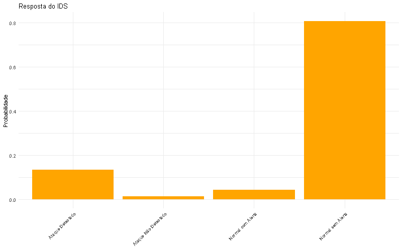

**Figura:** resposta do IDS. Ataques detectados correspondem a 0.135 da probabilidade total, ataques não detectados 0.015, tráfego normal com alerta 0.042 e tráfego normal sem alerta 0.807. A maior parte dos eventos corresponde a tráfego normal sem alerta.

```r
library(ggplot2)
library(base64enc)
library(IRdisplay)

# Caminho temporário para salvar a imagem
img_path <- tempfile(fileext = ".png")

# Dados
probs <- c(0.15 * 0.90, 0.15 * 0.10, 0.85 * 0.05, 0.85 * 0.95)
labels <- c("Ataque Detectado", "Ataque Não Detectado",
            "Normal com Alerta", "Normal sem Alerta")

df <- data.frame(
  Categoria = labels,
  Probabilidade = probs
)

# Salvar o gráfico
png(img_path, width = 800, height = 500)
ggplot(df, aes(x = Categoria, y = Probabilidade)) +
  geom_col(fill = "orange") +
  labs(title = "Resposta do IDS", y = "Probabilidade", x = NULL) +
  theme_minimal() +
  theme(axis.text.x = element_text(angle = 45, hjust = 1))
dev.off()

# Exibir embutido em Base64
img_b64 <- dataURI(file = img_path, mime = "image/png")

# exibir embutido em base64
display_html(sprintf('
<div style="text-align:center; max-width: 100%%;">
  <img src="%s" style="max-width: 100%%; height: auto;">
  <div style="margin-top:8px; font-size:90%%; color:#555; text-align:justify;">
    <b>Figura:</b> resposta do IDS. Ataques detectados correspondem a %.3f da probabilidade total,
    ataques não detectados %.3f, tráfego normal com alerta %.3f e tráfego normal sem alerta %.3f.
    A maior parte dos eventos corresponde a tráfego normal sem alerta.
  </div>
</div>
', img_b64, probs[1], probs[2], probs[3], probs[4]))
```